# Code: Analysis of messaging and financing on demand for non-traditional cookstove adoption in Uganda

Ellie Bauer, Eric Gero, Chunyu Qu, Braden Spratt

3/19/2021

# 1. Variables

## 1.1. Clean the data

## 1.2. Select Variables

### (1) Fixed Effect Variables - TBD

DATESURVEY  
UNIQUE_HHID  
PARISH

### (2) Houshold socio-economic and demographic variables - H

We ignore *gatherwood or buywood last month* due to possible error in memory and low impact from a past event.

1. FEMALE - gender(6 missing)
2. AGE - age(6 missing)
3. MARRIED - marital status(0 missing)
4. WIFECOOK - whether the wife is the primary cook(0 missing)
5. JOINTDECISION - whether husband and wife make decisions jointly(0 missing)
6. KNOWLUNCH_Dummy - Respondent knows how many people ate lunch
7. LUNCHYESTERDAY - How many ate lunch at HH yesterday (*252 missing*)
8. TYPICALNUMEATING_Dummy - Was Yesterday Lunch Typical (*252 missing*)
9. HOWPAID (*285 missing, ignored in regression*, as almost all the people paied in cash, we do not estimate the impact of paying in cash due to the extreme inbalance in different types of payment.)

### (3) Wealth variables - W

We ignore SPOUSE phone since there are 473 missing values (about 20% of whole data set).

1. HH_PHONES - Count of phones owned by household(0 missing)
2. INCOME_Dummy - Earns income(6 missing)
3. BICYCLE_DUMMY(4 missing), CAR_DUMMY(4 missing), MOTORCYCLE_DUMMY(4 missing)
4. RADIO_DUMMY(6 missing)
5. SELFEMPLOYED(*290 missing*)
6. TIME_EMPLOYED(*291 missing*)
7. COWS_Dummy(6 missing)
8. TV_Dummy(7 missing)
9. Total_Asset - this is computed with all the wealth dummies and durable good prices provided.

### (4) Cookstove variables - C

1.WOOD - the dummy of whether wood is the primary fuel(0 missing)  
2. TSF_PRIMARY - whether a three-stone fire is the primary stove. None means owning a stone stove(6 missing)  
3. BUYWOOD_DUMMY- buys wood last week or month(6 missing)  
4. GATHERWOOD_DUMMY - whether the household gathered wood last week(6 missing)  
5. STOVE1 - Type of stove already owned

### (5) Dependent variables - Y

1. MAXBID
2. MAXBIDNOVEL

### (6) Gender interaction varibles

Female_AGE  
Female_MARRIED  
Female_WIFECOOK  
Female_JOINTDECISION  
Female_KNOWLUNCH_Dummy  
Female_LUNCHYESTERDAY  
Female_HH_PHONES  
Female_INCOME_Dummy  
Female_MOTORCYCLE_DUMMY  
Female_CAR_DUMMY  
Female_RADIO_DUMMY  
Female_COWS_Dummy  
Female_TV_Dummy  
Female_WOOD  
Female_TSF_PRIMARY  
Female_BUYWOOD_DUMMY  
Female_GATHERWOOD_DUMMY

## 1.3. Overview of auctions - Table 1

HH received messages and reported is 2234. Payment type recorded is 2018

```r
## Toal HH amount
length(Fulldata$HHID)
```

```
## [1] 2303
```

```r
## HH's that took Demand Determinant Survey
length(Data$DATESURVEY)
```

```
## [1] 2234
```

```r
## HH's that bid on Pay Within a Week Auction - number of wining
# 2125
sum(Data$WIN_TRADITIONAL_OFFER, na.rm=T)
```

```
## [1] 47
```

```r
## HH's that bid on time payment - number of wining
# 2135
sum(Data$WIN_NOVEL_OFFER, na.rm=T)
```

```
## [1] 45
```

```r
## HH's are female
sum(Fulldata$FEMALE,na.rm = T)
```

```
## [1] 1617
```

```r
mean(Fulldata$MAXBID, na.rm=T)
```

```
## [1] 4.858061
```

```r
sd(Fulldata$MAXBID, na.rm=T)
```

```
## [1] 4.650002
```

```r
t.test(Fulldata$MAXBID)
```

```
##
##  One Sample t-test
##
## data:  Fulldata$MAXBID
## t = 48.16, df = 2124, p-value < 2.2e-16
## alternative hypothesis: true mean is not equal to 0
## 95 percent confidence interval:
##  4.660241 5.055881
## sample estimates:
## mean of x
##  4.858061
```

```r
median(Fulldata$MAXBID, na.rm=T)
```

```
## [1] 3.976143
```

```r
mean(Fulldata$MAXBIDNOVEL, na.rm=T)
```

```
## [1] 6.830965
```

```r
sd(Fulldata$MAXBIDNOVEL, na.rm=T)
```

```
## [1] 6.384978
```

```r
t.test(Fulldata$MAXBIDNOVEL)
```

```
##
##  One Sample t-test
##
## data:  Fulldata$MAXBIDNOVEL
## t = 49.434, df = 2134, p-value < 2.2e-16
## alternative hypothesis: true mean is not equal to 0
## 95 percent confidence interval:
##  6.559974 7.101957
## sample estimates:
## mean of x
##  6.830965
```

```r
median(Fulldata$MAXBIDNOVEL, na.rm=T)
```

```
## [1] 4.771372
```

For tradition bids

```r
# Winning bids
tradition = Fulldata[which(Fulldata$WIN_TRADITIONAL_OFFER== 1), ]
length(tradition$WINNING_AMOUNT)-sum(is.na(tradition$WINNING_AMOUNT))
```

```
## [1] 47
```

```r
mean(tradition$WINNING_AMOUNT)
```

```
## [1] 12.86748
```

```r
sd(tradition$WINNING_AMOUNT)
```

```
## [1] 5.073302
```

```r
t.test(tradition$WINNING_AMOUNT)
```

```
##
##  One Sample t-test
##
## data:  tradition$WINNING_AMOUNT
## t = 17.388, df = 46, p-value < 2.2e-16
## alternative hypothesis: true mean is not equal to 0
## 95 percent confidence interval:
##  11.37790 14.35705
## sample estimates:
## mean of x
##  12.86748
```

```r
median(tradition$WINNING_AMOUNT)
```

```
## [1] 11.92843
```

```r
# Second price paid
47 -sum(is.na(tradition$PAID_PRICE))
```

```
## [1] 38
```

```r
mean(tradition$PAID_PRICE,na.rm = T)
```

```
## [1] 13.35147
```

```r
sd(tradition$PAID_PRICE,na.rm = T)
```

```
## [1] 5.163305
```

```r
t.test(tradition$PAID_PRICE)
```

```
##
##  One Sample t-test
##
## data:  tradition$PAID_PRICE
## t = 15.94, df = 37, p-value < 2.2e-16
## alternative hypothesis: true mean is not equal to 0
## 95 percent confidence interval:
##  11.65433 15.04861
## sample estimates:
## mean of x
##  13.35147
```

```r
median(tradition$PAID_PRICE,na.rm = T)
```

```
## [1] 11.92843
```

```r
# Deposit paid for stove
47 -sum(is.na(tradition$DEPOSIT_ON_SALES_DAY))
```

```
## [1] 47
```

```r
mean(tradition$DEPOSIT_ON_SALES_DAY)
```

```
## [1] 5.6089
```

```r
sd(tradition$DEPOSIT_ON_SALES_DAY)
```

```
## [1] 4.367847
```

```r
t.test(tradition$DEPOSIT_ON_SALES_DAY)
```

```
##
##  One Sample t-test
##
## data:  tradition$DEPOSIT_ON_SALES_DAY
## t = 8.8036, df = 46, p-value = 1.991e-11
## alternative hypothesis: true mean is not equal to 0
## 95 percent confidence interval:
##  4.326452 6.891348
## sample estimates:
## mean of x
##    5.6089
```

```r
median(tradition$DEPOSIT_ON_SALES_DAY)
```

```
## [1] 3.976143
```

```r
# Stoves returned
sum(tradition$PAID_IN_FULL)
```

```
## [1] 18
```

```r
sum(tradition$RETURNED)
```

```
## [1] 4
```

```r
sum(tradition$DEFAULT)
```

```
## [1] 2
```

```r
sum(tradition$PAYMENT_COMPLETE)
```

```
## [1] 41
```

For time payment

```r
timepay = Fulldata[which(Fulldata$WIN_NOVEL_OFFER== 1), ]
length(timepay$WINNING_AMOUNT)-sum(is.na(timepay$WINNING_AMOUNT))
```

```
## [1] 45
```

```r
mean(timepay$WINNING_AMOUNT)
```

```
## [1] 16.77932
```

```r
sd(timepay$WINNING_AMOUNT)
```

```
## [1] 6.375708
```

```r
t.test(timepay$WINNING_AMOUNT)
```

```
##
##  One Sample t-test
##
## data:  timepay$WINNING_AMOUNT
## t = 17.654, df = 44, p-value < 2.2e-16
## alternative hypothesis: true mean is not equal to 0
## 95 percent confidence interval:
##  14.86385 18.69480
## sample estimates:
## mean of x
##  16.77932
```

```r
median(timepay$WINNING_AMOUNT)
```

```
## [1] 15.90457
```

```r
45 -sum(is.na(timepay$PAID_PRICE))
```

```
## [1] 35
```

```r
mean(timepay$PAID_PRICE,na.rm = T)
```

```
## [1] 17.04061
```

```r
sd(timepay$PAID_PRICE,na.rm = T)
```

```
## [1] 6.492162
```

```r
t.test(timepay$PAID_PRICE)
```

```
##
##  One Sample t-test
##
## data:  timepay$PAID_PRICE
## t = 15.529, df = 34, p-value < 2.2e-16
## alternative hypothesis: true mean is not equal to 0
## 95 percent confidence interval:
##  14.81048 19.27075
## sample estimates:
## mean of x
##  17.04061
```

```r
median(timepay$PAID_PRICE,na.rm = T)
```

```
## [1] 15.90457
```

```r
45 -sum(is.na(timepay$DEPOSIT_ON_SALES_DAY))
```

```
## [1] 45
```

```r
mean(timepay$DEPOSIT_ON_SALES_DAY)
```

```
## [1] 5.058538
```

```r
sd(timepay$DEPOSIT_ON_SALES_DAY)
```

```
## [1] 2.772161
```

```r
t.test(timepay$DEPOSIT_ON_SALES_DAY)
```

```
##
##  One Sample t-test
##
## data:  timepay$DEPOSIT_ON_SALES_DAY
## t = 12.241, df = 44, p-value = 9.187e-16
## alternative hypothesis: true mean is not equal to 0
## 95 percent confidence interval:
##  4.225688 5.891387
## sample estimates:
## mean of x
##  5.058538
```

```r
median(timepay$DEPOSIT_ON_SALES_DAY)
```

```
## [1] 4.771372
```

```r
sum(timepay$PAID_IN_FULL)
```

```
## [1] 4
```

```r
sum(timepay$RETURNED)
```

```
## [1] 7
```

```r
sum(timepay$DEFAULT)
```

```
## [1] 4
```

```r
sum(timepay$PAYMENT_COMPLETE)
```

```
## [1] 34
```

## 1.4 Overview of message groups - Table 2

Together with balance check later

```r
No_Message = Fulldata[which(Fulldata$GROUP== "No Message"), ]
Saves_Time_Money  = Fulldata[which(Fulldata$GROUP== "Saves Time and Money"), ]
Improves_Health = Fulldata[which(Fulldata$GROUP== "Improves Health"), ]
Time_Money_Health = Fulldata[which(Fulldata$GROUP== "Time, Money and Health"), ]

library(data.table)
table2 = transpose(data.frame(c(mean(No_Message$MAXBID,na.rm = T),sd(No_Message$MAXBID,na.rm = T),median(No_Message$MAXBID,na.rm = T), sum(No_Message$WIN_TRADITIONAL_OFFER,na.rm = T)),

c(mean(Saves_Time_Money$MAXBID,na.rm = T),sd(Saves_Time_Money$MAXBID,na.rm = T),median(Saves_Time_Money$MAXBID,na.rm = T), sum(Saves_Time_Money$WIN_TRADITIONAL_OFFER,na.rm = T)),

c(mean(Improves_Health$MAXBID,na.rm = T),sd(Improves_Health$MAXBID,na.rm = T),median(Improves_Health$MAXBID,na.rm = T), sum(Improves_Health$WIN_TRADITIONAL_OFFER,na.rm = T)),

c(mean(Time_Money_Health$MAXBID,na.rm = T),sd(Time_Money_Health$MAXBID,na.rm = T),median(Time_Money_Health$MAXBID,na.rm = T), sum(Time_Money_Health$WIN_TRADITIONAL_OFFER,na.rm = T)),

c(mean(No_Message$MAXBIDNOVEL,na.rm = T),sd(No_Message$MAXBIDNOVEL,na.rm = T),median(No_Message$MAXBIDNOVEL,na.rm = T), sum(No_Message$WIN_TRADITIONAL_OFFER,na.rm = T)),

c(mean(Saves_Time_Money$MAXBIDNOVEL,na.rm = T),sd(Saves_Time_Money$MAXBIDNOVEL,na.rm = T),median(Saves_Time_Money$MAXBIDNOVEL,na.rm = T), sum(Saves_Time_Money$WIN_TRADITIONAL_OFFER,na.rm = T)),

c(mean(Improves_Health$MAXBIDNOVEL,na.rm = T),sd(Improves_Health$MAXBIDNOVEL,na.rm = T),median(Improves_Health$MAXBIDNOVEL,na.rm = T), sum(Improves_Health$WIN_TRADITIONAL_OFFER,na.rm = T)),

c(mean(Time_Money_Health$MAXBIDNOVEL,na.rm = T),sd(Time_Money_Health$MAXBIDNOVEL,na.rm = T),median(Time_Money_Health$MAXBIDNOVEL,na.rm = T), sum(Time_Money_Health$WIN_TRADITIONAL_OFFER,na.rm = T))))

colnames(table2) <- c("mean", "sd","median", "p-value")

table2
```

```
##       mean       sd   median p-value
## 1 4.579009 4.819203 3.976143      10
## 2 4.474517 4.135269 3.976143       7
## 3 5.503134 5.220355 3.976143      19
## 4 4.877390 4.281005 3.976143      11
## 5 6.732729 6.874040 4.771372      10
## 6 7.171327 6.376340 5.964215       7
## 7 6.815442 6.349570 4.771372      19
## 8 6.608321 5.903200 4.771372      11
```

*Perform Joint test*  
Note the assumptions for the F Test for comparing three or more means include:  
1. The populations from which the samples were obtained must be normally or approximately normally distributed.  
2. The samples must be independent of one another.  
3. The variances of the populations must be equal.

Specifically, we cannot gaurantee there is no endogeneity issue, which will violate assumption 2 and 3. To safely test the hypothesis that the means of all the groups are equal, we adopt both ANOVA and Kruskal-Wallis test for comparison

We report the nonparametric joint test for the means here

```r
Fulldata$GROUP<- factor(Fulldata$GROUP, levels = c("No Message", "Improves Health", "Saves Time and Money","Time, Money and Health" ))

Maxbid_mean <- tapply(Fulldata$MAXBID, Fulldata$GROUP)
Maxbid_sd <- tapply(Fulldata$MAXBID, Fulldata$GROUP, sd)

# ANOVA F-test
Maxbid_ANOVA <- lm(MAXBID ~ GROUP, Fulldata)
anova(Maxbid_ANOVA)
```

```
## Analysis of Variance Table
##
## Response: MAXBID
##             Df Sum Sq Mean Sq F value   Pr(>F)
## GROUP        3    337 112.216  5.2207 0.001364 **
## Residuals 2121  45590  21.494
## ---
## Signif. codes:  0 '***' 0.001 '**' 0.01 '*' 0.05 '.' 0.1 ' ' 1
```

```r
# Nonparametric test
kruskal.test(MAXBID ~ GROUP, Fulldata)
```

```
##
##  Kruskal-Wallis rank sum test
##
## data:  MAXBID by GROUP
## Kruskal-Wallis chi-squared = 11.644, df = 3, p-value = 0.008708
```

```r
Fulldata$GROUP<- factor(Fulldata$GROUP, levels = c("No Message", "Improves Health", "Saves Time and Money","Time, Money and Health" ))

Maxbidnovel_mean <- tapply(Fulldata$MAXBIDNOVEL, Fulldata$GROUP)
Maxbidnovel_sd <- tapply(Fulldata$MAXBIDNOVEL, Fulldata$GROUP, sd)

# ANOVA F-test
Maxbidnovel_ANOVA <- lm(MAXBIDNOVEL ~ GROUP, Fulldata)
anova(Maxbidnovel_ANOVA)
```

```
## Analysis of Variance Table
##
## Response: MAXBIDNOVEL
##             Df Sum Sq Mean Sq F value Pr(>F)
## GROUP        3     94  31.406  0.7701 0.5107
## Residuals 2131  86905  40.781
```

```r
# Nonparametric test
kruskal.test(MAXBIDNOVEL ~ GROUP, Fulldata)
```

```
##
##  Kruskal-Wallis rank sum test
##
## data:  MAXBIDNOVEL by GROUP
## Kruskal-Wallis chi-squared = 5.585, df = 3, p-value = 0.1336
```

# 2 Balance check

Check if randomization is successful.
$$Y_{i}=\beta_{0}+\beta_{1}Message_i+\epsilon_i$$
$$X_{i}=\beta_{0}+\beta_{1}Message_i+\epsilon_i$$
where $Y_{i0}$ in (1) denotes the bidprice and novel bid price, $X_{i0}$ in (1) denotes all the explanatory variables in the following section (H, W, C). $Message_i$ is the variable of the four groups.

Next, we perform an overall joint test of balance in characteristics using the following specification
$$Message_{i}=\alpha+\beta'Y_{i}+\gamma'X_{i}+\epsilon_i$$

## 2.1 A detailed illustration on age

### (1) Table of descriptive statistics by treatment group

```r
### Number of missing values
sum(is.na(Data$AGE))
```

```
## [1] 6
```

```r
### 6 missing values reported

### Clean the incomplete observations, note: save in a new "data" in lower
data=Data[!is.na(Data$AGE), ]

### Set the preferred ordering of groups in tables and graphs
data$GROUP<- factor(data$GROUP, levels = c("No Message", "Improves Health", "Saves Time and Money","Time, Money and Health" ))

### Table of descriptive statistics by treatment group
Age_mean <- tapply(data$AGE, data$GROUP, mean)
Age_sd <- tapply(data$AGE, data$GROUP, sd)
n         <- tapply(data$AGE, data$GROUP, length)
data.frame(mean = Age_mean, std.dev = Age_sd, n = n)
```

```
##                            mean  std.dev   n
## No Message             38.76842 13.56398 570
## Improves Health        40.39640 13.89652 555
## Saves Time and Money   39.45971 13.32264 546
## Time, Money and Health 39.09515 13.42163 557
```

### (2) Visualization with strip chart - For non-technical Memo

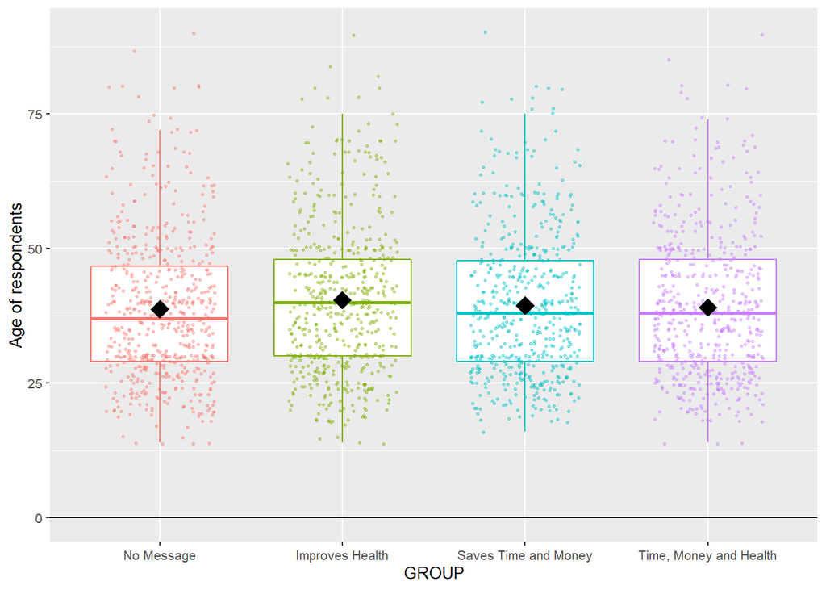

```r
ggplot(data, aes(GROUP, AGE, color=GROUP)) +
  geom_boxplot(show.legend=FALSE, outlier.shape = NA) +
  geom_jitter(width=0.3, alpha = 0.4, size=0.5, show.legend=FALSE) +
  ylab(label = "Age of respondents") +
  stat_summary(fun = "mean", size = 5, geom = "point", shape=18, color = 'black') +
  geom_hline(yintercept = 0) +
  theme_grey(base_size=10)
```

### (3) Blance Check - Fixed effects ANOVA and Nonparametric Test- For Technical Memo

We adopt both ANOVA and Kruskal test here, again.

```r
### Anova Test
Age_ANOVA <- lm(AGE ~ GROUP, data)
anova(Age_ANOVA)
```

```
## Analysis of Variance Table
##
## Response: AGE
##             Df Sum Sq Mean Sq F value Pr(>F)
## GROUP        3    831  276.90  1.5073 0.2107
## Residuals 2224 408562  183.71
```

```r
### Krusal-Wallis test
kruskal.test(AGE ~ GROUP, data )
```

```
##
##  Kruskal-Wallis rank sum test
##
## data:  AGE by GROUP
## Kruskal-Wallis chi-squared = 4.665, df = 3, p-value = 0.198
```

Both tests do not reject the null hypothesis, implying no significant differences in age among the four groups.

## 2.2 All Variables

### 2.2.1 Houshold socio-economic and demographic variables - H

We ignore *gatherwood or buywood last month* due to possible error in memory and low impact from a past event.

1.FEMALE

```r
### Summary Stats
### Use the dummy for female, delete all the missing values
data=Data[!is.na(Data$FEMALE), ]
data$GROUP<- factor(data$GROUP, levels = c("No Message", "Improves Health", "Saves Time and Money","Time, Money and Health" ))
FEMALE_mean <- tapply(data$FEMALE, data$GROUP, mean)
FEMALE_sd <- tapply(data$FEMALE, data$GROUP, sd)
n <- tapply(data$FEMALE, data$GROUP, length)
data.frame(mean = FEMALE_mean, std.dev = FEMALE_sd, n = n)
```

```
##                             mean   std.dev   n
## No Message             0.6912281 0.4623926 570
## Improves Health        0.7009009 0.4582764 555
## Saves Time and Money   0.7307692 0.4439668 546
## Time, Money and Health 0.7199282 0.4494377 557
```

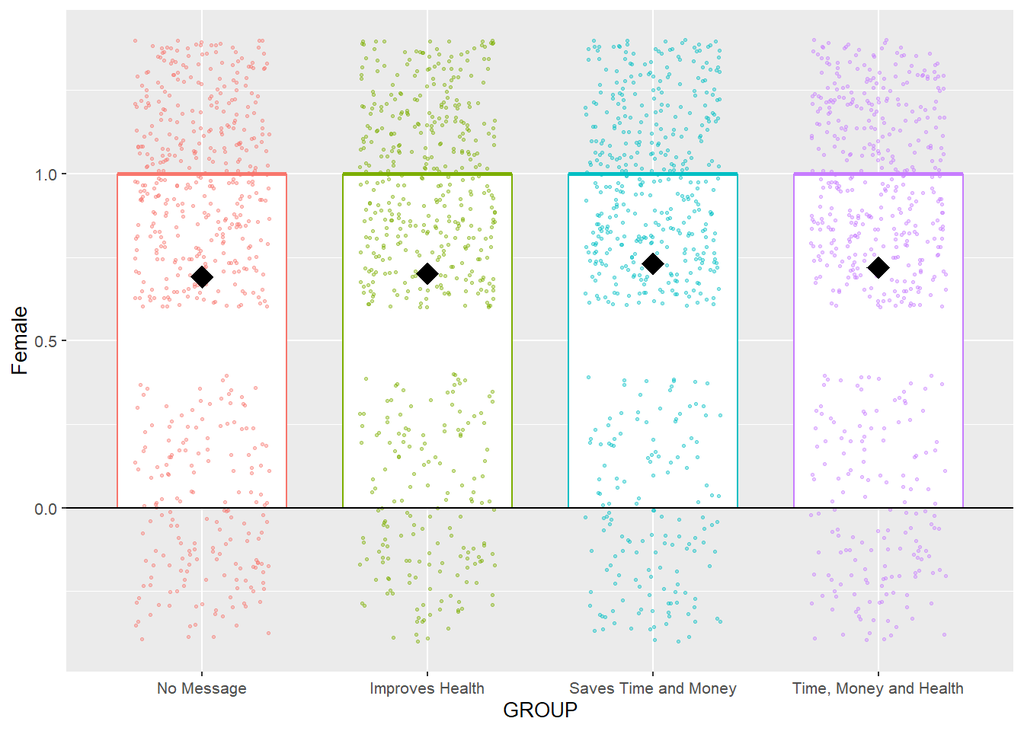

```r
### Visualization
ggplot(data, aes(GROUP, FEMALE, color=GROUP)) +
  geom_boxplot(show.legend=FALSE, outlier.shape = NA) +
  geom_jitter(width=0.3, alpha = 0.4, size=0.5, show.legend=FALSE) +
  ylab(label = "Female") +
  stat_summary(fun = "mean", size = 5, geom = "point", shape=18, color = 'black') +
  geom_hline(yintercept = 0) +
  theme_grey(base_size=10)
```

```r
### Krusal-Wallis test
kruskal.test(GENDER ~ GROUP, data )
```

```
##
##  Kruskal-Wallis rank sum test
##
## data:  GENDER by GROUP
## Kruskal-Wallis chi-squared = 2.608, df = 3, p-value = 0.4561
```

3. MARRIED - marital status. We use MARRIED for balance check based on the distribution of the 5 different types. We use STATUS for visualization.

```r
### Summary Stats
### Use the dummy for STATUS, delete all the missing values (not clean upon MARRIED since it is a dummy without missing values, which means new error will be brought)
data=Data[!is.na(Data$STATUS), ]
data$GROUP<- factor(data$GROUP, levels = c("No Message", "Improves Health", "Saves Time and Money","Time, Money and Health" ))
MARRIED_mean <- tapply(data$MARRIED, data$GROUP, mean)
MARRIED_sd <- tapply(data$MARRIED, data$GROUP, sd)
n <- tapply(data$MARRIED, data$GROUP, length)
data.frame(mean = MARRIED_mean, std.dev = MARRIED_sd, n = n)
```

```
##                             mean   std.dev   n
## No Message             0.7789474 0.4153203 570
## Improves Health        0.8072072 0.3948476 555
## Saves Time and Money   0.7875458 0.4094196 546
## Time, Money and Health 0.8132855 0.3900325 557
```

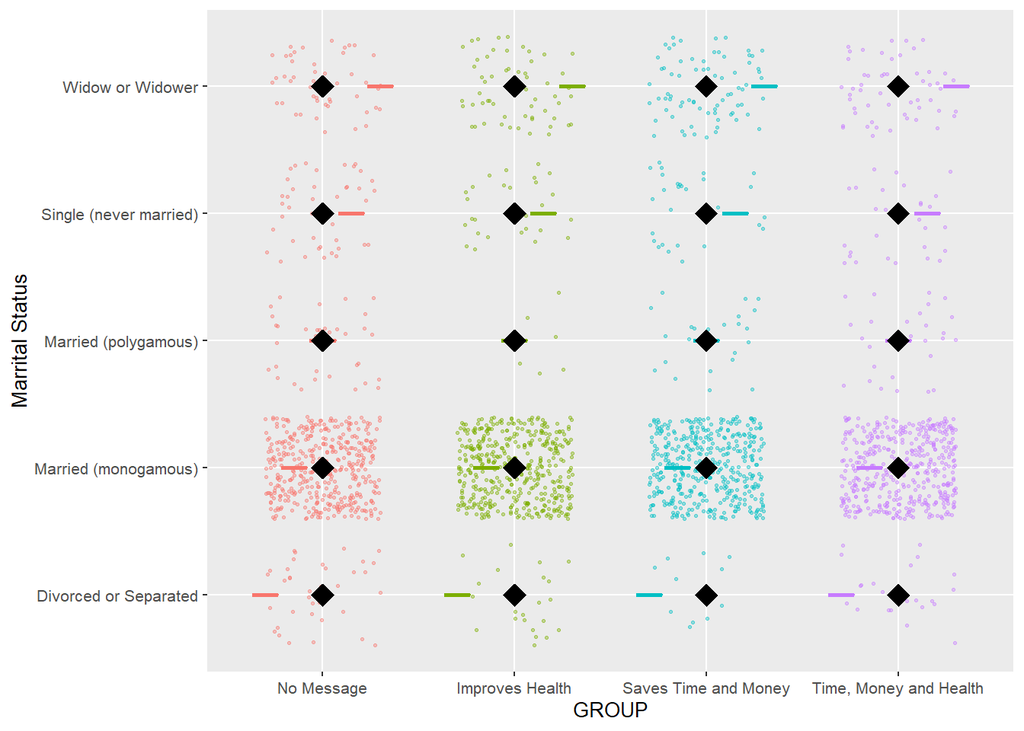

```r
### Visualization
ggplot(data, aes(GROUP, STATUS, color=GROUP)) +
  geom_boxplot(show.legend=FALSE, outlier.shape = NA) +
  geom_jitter(width=0.3, alpha = 0.4, size=0.5, show.legend=FALSE) +
  ylab(label = "Marrital Status") +
  stat_summary(fun = "mean", size = 5, geom = "point", shape=18, color = 'black') +
  geom_hline(yintercept = 0) +
  theme_grey(base_size=10)
```

```r
### Krusal-Wallis test
kruskal.test(STATUS ~ GROUP, data )
```

```
##
##  Kruskal-Wallis rank sum test
##
## data:  STATUS by GROUP
## Kruskal-Wallis chi-squared = 9.5644, df = 3, p-value = 0.02266
```

4. WIFECOOK - whether the wife is the primary cook. We use WIFECOOK for balance check based on the distribution of the 4 different types. We use PRIMARYCOOK2 for visualization.

```r
data=Data[!is.na(Data$PRIMARYCOOK2), ]
data$GROUP<- factor(data$GROUP, levels = c("No Message", "Improves Health", "Saves Time and Money","Time, Money and Health" ))
WIFECOOK_mean <- tapply(data$WIFECOOK, data$GROUP, mean)
WIFECOOK_sd <- tapply(data$WIFECOOK, data$GROUP, sd)
n <- tapply(data$WIFECOOK, data$GROUP, length)
data.frame(mean = WIFECOOK_mean, std.dev = WIFECOOK_sd, n = n)
```

```
##                             mean   std.dev   n
## No Message             0.8596491 0.3476558 570
## Improves Health        0.9189189 0.2732058 555
## Saves Time and Money   0.8681319 0.3386576 546
## Time, Money and Health 0.8420108 0.3650588 557
```

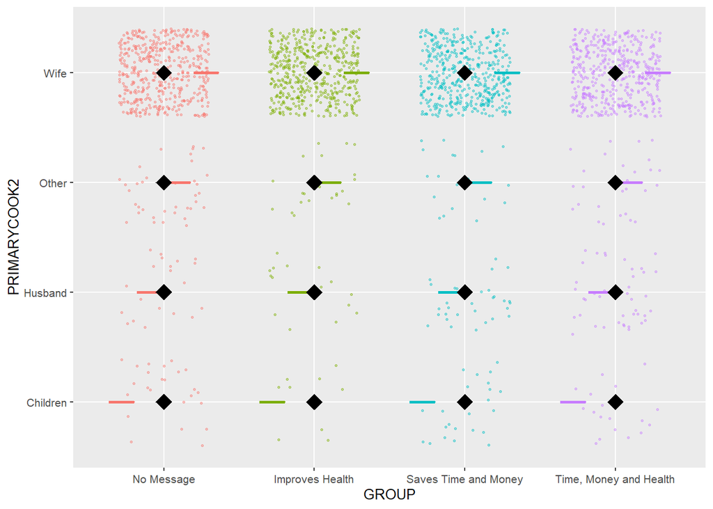

```r
### Visualization
ggplot(data, aes(GROUP, PRIMARYCOOK2, color=GROUP)) +
  geom_boxplot(show.legend=FALSE, outlier.shape = NA) +
  geom_jitter(width=0.3, alpha = 0.4, size=0.5, show.legend=FALSE) +
  ylab(label = "PRIMARYCOOK2") +
  stat_summary(fun = "mean", size = 5, geom = "point", shape=18, color = 'black') +
  geom_hline(yintercept = 0) +
  theme_grey(base_size=10)
```

```r
### Krusal-Wallis test
kruskal.test(WIFECOOK ~ GROUP, data )
```

```
##
##  Kruskal-Wallis rank sum test
##
## data:  WIFECOOK by GROUP
## Kruskal-Wallis chi-squared = 16.288, df = 3, p-value = 0.0009898
```

5. JOINTDECISION - whether husband and wife make decisions jointly. We use JOINTDECISION for balance check based on the distribution of the 5 different types. We use DECISIONS2 for visualization.

```r
data=Data[!is.na(Data$DECISIONS2), ]
data$GROUP<- factor(data$GROUP, levels = c("No Message", "Improves Health", "Saves Time and Money","Time, Money and Health" ))
JOINTDECISION_mean <- tapply(data$JOINTDECISION, data$GROUP, mean)
JOINTDECISION_sd <- tapply(data$JOINTDECISION, data$GROUP, sd)
n <- tapply(data$JOINTDECISION, data$GROUP, length)
data.frame(mean = JOINTDECISION_mean, std.dev = JOINTDECISION_sd, n = n)
```

```
##                             mean   std.dev   n
## No Message             0.4315789 0.4957315 570
## Improves Health        0.3387387 0.4737079 555
## Saves Time and Money   0.4542125 0.4983557 546
## Time, Money and Health 0.5529623 0.4976340 557
```

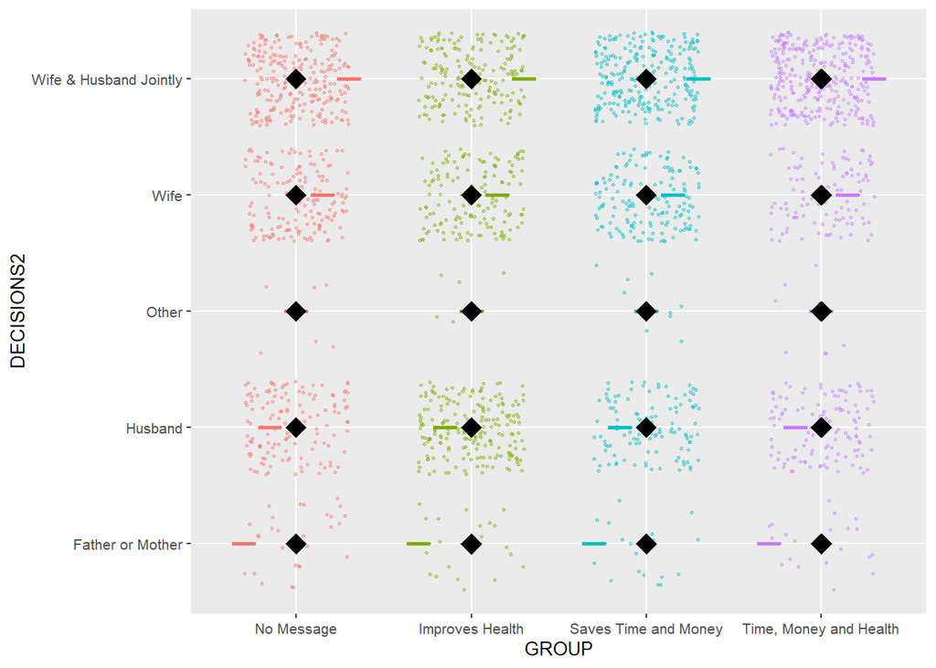

```r
### Visualization
ggplot(data, aes(GROUP, DECISIONS2, color=GROUP)) +
  geom_boxplot(show.legend=FALSE, outlier.shape = NA) +
  geom_jitter(width=0.3, alpha = 0.4, size=0.5, show.legend=FALSE) +
  ylab(label = "DECISIONS2") +
  stat_summary(fun = "mean", size = 5, geom = "point", shape=18, color = 'black') +
  geom_hline(yintercept = 0) +
  theme_grey(base_size=10)
```

```r
### Krusal-Wallis test
kruskal.test(JOINTDECISION ~ GROUP, data )
```

```
##
##  Kruskal-Wallis rank sum test
##
## data:  JOINTDECISION by GROUP
## Kruskal-Wallis chi-squared = 52.253, df = 3, p-value = 2.646e-11
```

6. KNOWLUNCH - Respondent knows how many people ate lunch

```r
### Create KNOWLUNCH_Dummy
data_plus=data
data=Data[!is.na(Data$KNOWLUNCH), ]
data$KNOWLUNCH_Dummy = data$KNOWLUNCH
data$KNOWLUNCH_Dummy[data$KNOWLUNCH_Dummy == "No"] <- 0
data$KNOWLUNCH_Dummy[data$KNOWLUNCH_Dummy == "Yes"] <- 1
data_plus$KNOWLUNCH_Dummy = data$KNOWLUNCH_Dummy


data$GROUP<- factor(data$GROUP, levels = c("No Message", "Improves Health", "Saves Time and Money","Time, Money and Health" ))
KNOWLUNCH_Dummy_mean <- tapply(as.numeric(data$KNOWLUNCH_Dummy), data$GROUP, mean)
KNOWLUNCH_Dummy_sd <- tapply(as.numeric((data$KNOWLUNCH_Dummy)), data$GROUP, sd)
n <- tapply(data$KNOWLUNCH_Dummy, data$GROUP, length)
data.frame(mean = KNOWLUNCH_Dummy_mean, std.dev = KNOWLUNCH_Dummy_sd, n = n)
```

```
##                             mean   std.dev   n
## No Message             0.9263158 0.2614858 570
## Improves Health        0.9837838 0.1264201 555
## Saves Time and Money   0.7399267 0.4390766 546
## Time, Money and Health 0.9299820 0.2554066 557
```

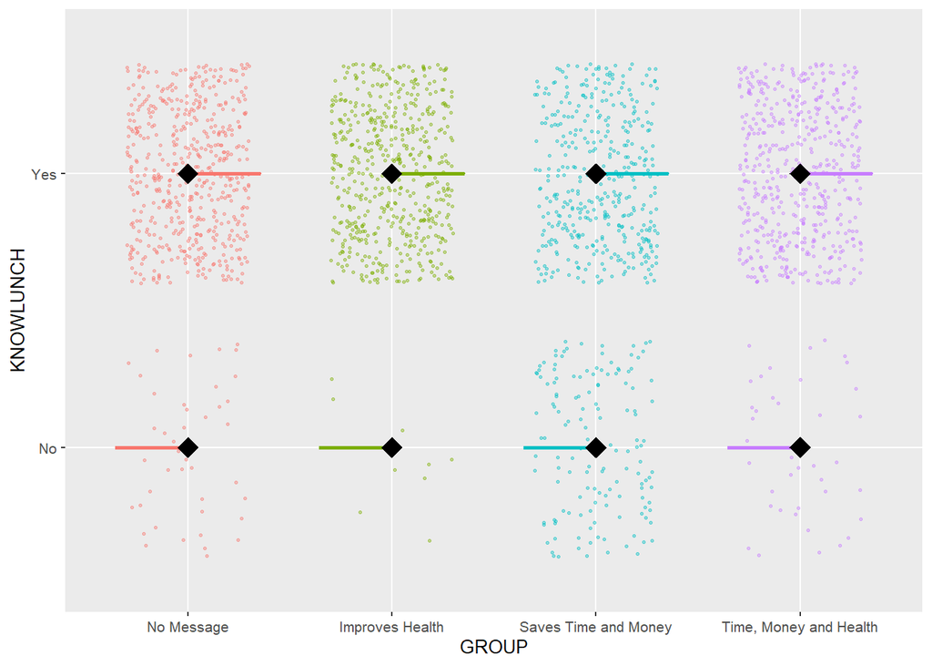

```r
### Visualization
ggplot(data, aes(GROUP, KNOWLUNCH, color=GROUP)) +
  geom_boxplot(show.legend=FALSE, outlier.shape = NA) +
  geom_jitter(width=0.3, alpha = 0.4, size=0.5, show.legend=FALSE) +
  ylab(label = "KNOWLUNCH") +
  stat_summary(fun = "mean", size = 5, geom = "point", shape=18, color = 'black') +
  geom_hline(yintercept = 0) +
  theme_grey(base_size=10)
```

```r
### Krusal-Wallis test
kruskal.test(KNOWLUNCH_Dummy ~ GROUP, data )
```

```
##
##  Kruskal-Wallis rank sum test
##
## data:  KNOWLUNCH_Dummy by GROUP
## Kruskal-Wallis chi-squared = 200.84, df = 3, p-value < 2.2e-16
```

```r
data_plus$KNOWLUNCH_Dummy=as.numeric(data_plus$KNOWLUNCH_Dummy)
```

7. LUNCHYESTERDAY - How many ate lunch at HH yesterday (252 missing)

```r
### Summary
data=Data[!is.na(Data$LUNCHYESTERDAY), ]

data$GROUP<- factor(data$GROUP, levels = c("No Message", "Improves Health", "Saves Time and Money","Time, Money and Health" ))
LUNCHYESTERDAY_mean <- tapply(as.numeric(data$LUNCHYESTERDAY), data$GROUP, mean)
LUNCHYESTERDAY_sd <- tapply(as.numeric((data$LUNCHYESTERDAY)), data$GROUP, sd)
n <- tapply(data$LUNCHYESTERDAY, data$GROUP, length)
data.frame(mean = LUNCHYESTERDAY_mean, std.dev = LUNCHYESTERDAY_sd, n = n)
```

```
##                            mean  std.dev   n
## No Message             4.614367 2.286874 529
## Improves Health        4.595238 2.371678 546
## Saves Time and Money   4.581683 2.450657 404
## Time, Money and Health 4.349421 2.251050 518
```

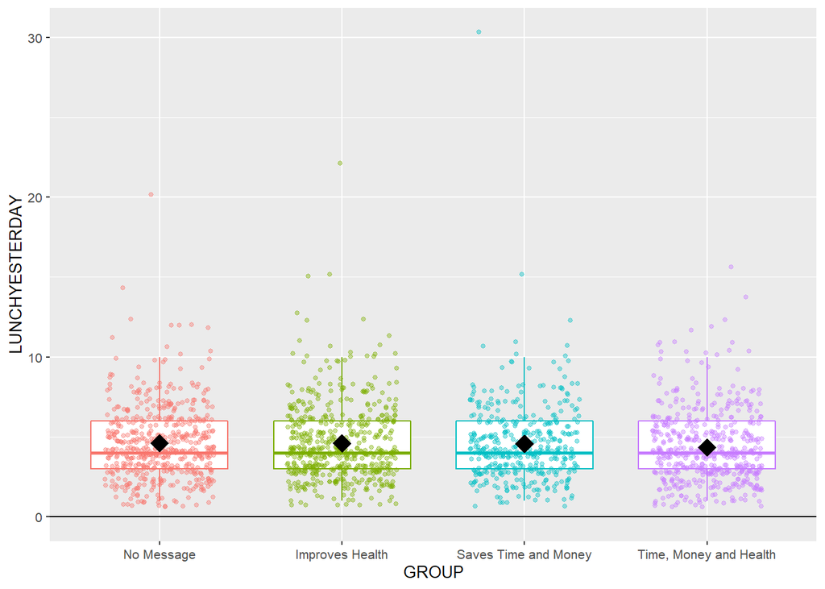

```r
### Visualization
ggplot(data, aes(GROUP, LUNCHYESTERDAY, color=GROUP)) +
  geom_boxplot(show.legend=FALSE, outlier.shape = NA) +
  geom_jitter(width=0.3, alpha = 0.4, size=1, show.legend=FALSE) +
  ylab(label = "LUNCHYESTERDAY") +
  stat_summary(fun = "mean", size = 5, geom = "point", shape=18, color = 'black') +
  geom_hline(yintercept = 0) +
  theme_grey(base_size=10)
```

```r
### Krusal-Wallis test
kruskal.test(LUNCHYESTERDAY ~ GROUP, data )
```

```
##
##  Kruskal-Wallis rank sum test
##
## data:  LUNCHYESTERDAY by GROUP
## Kruskal-Wallis chi-squared = 5.7539, df = 3, p-value = 0.1242
```

8. TYPICALNUMEATING_Dummy - Was Yesterday Lunch Typical (252 missing) - Not included in joint test

```r
### Create TYPICALNUMEATING_Dummy
data=data_plus
data$TYPICALNUMEATING_Dummy = data$TYPICALNUMEATING
data$TYPICALNUMEATING_Dummy[data$TYPICALNUMEATING_Dummy != "Yes"] <- 0
data$TYPICALNUMEATING_Dummy[data$TYPICALNUMEATING_Dummy == "Yes"] <- 1
data_plus$TYPICALNUMEATING_Dummy = data$TYPICALNUMEATING_Dummy

data=data[!is.na(data$TYPICALNUMEATING_Dummy), ]
data$GROUP<- factor(data$GROUP, levels = c("No Message", "Improves Health", "Saves Time and Money","Time, Money and Health" ))
TYPICALNUMEATING_Dummy_mean <- tapply(as.numeric(data$TYPICALNUMEATING_Dummy), data$GROUP, mean)
TYPICALNUMEATING_Dummy_sd <- tapply(as.numeric((data$TYPICALNUMEATING_Dummy)), data$GROUP, sd)
n <- tapply(data$TYPICALNUMEATING_Dummy, data$GROUP, length)
data.frame(mean = TYPICALNUMEATING_Dummy_mean, std.dev = TYPICALNUMEATING_Dummy_sd, n = n)
```

```
##                             mean   std.dev   n
## No Message             0.4678030 0.4994355 528
## Improves Health        0.5622711 0.4965621 546
## Saves Time and Money   0.6197531 0.4860479 405
## Time, Money and Health 0.4131274 0.4928713 518
```

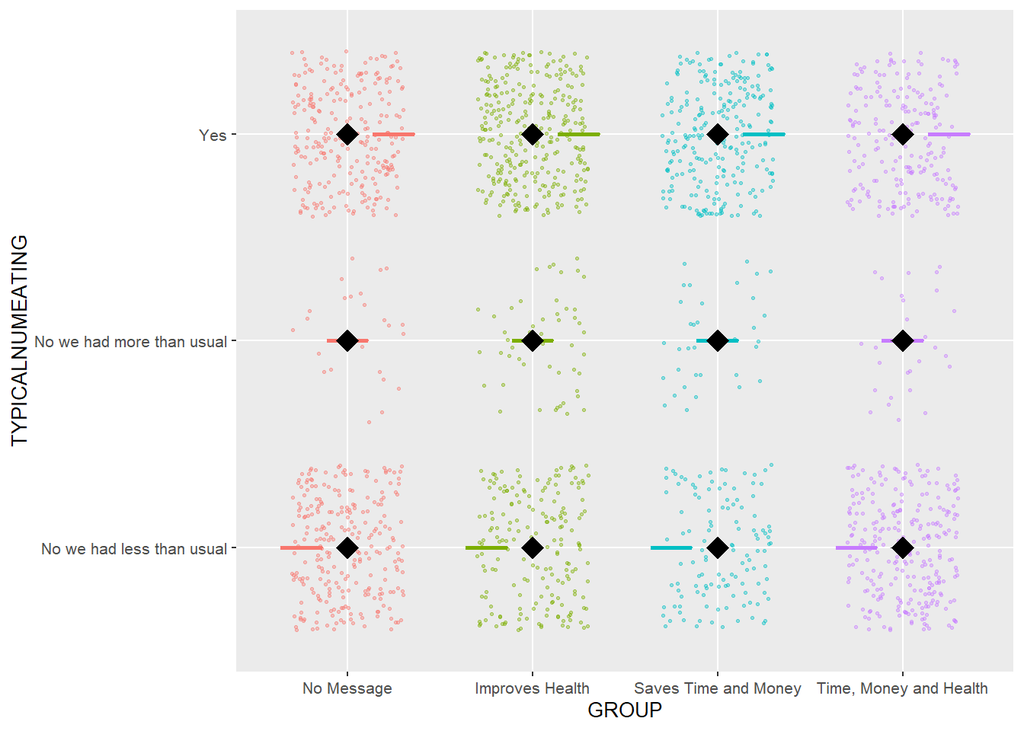

```r
### Visualization
ggplot(data, aes(GROUP, TYPICALNUMEATING, color=GROUP)) +
  geom_boxplot(show.legend=FALSE, outlier.shape = NA) +
  geom_jitter(width=0.3, alpha = 0.4, size=0.5, show.legend=FALSE) +
  ylab(label = "TYPICALNUMEATING") +
  stat_summary(fun = "mean", size = 5, geom = "point", shape=18, color = 'black') +
  geom_hline(yintercept = 0) +
  theme_grey(base_size=10)
```

```r
### Krusal-Wallis test
kruskal.test(TYPICALNUMEATING_Dummy ~ GROUP, data )
```

```
##
##  Kruskal-Wallis rank sum test
##
## data:  TYPICALNUMEATING_Dummy by GROUP
## Kruskal-Wallis chi-squared = 48.682, df = 3, p-value = 1.525e-10
```

9. HOWPAID

```r
### Create Cashpaid_Dummy
data=data_plus
data$CASHPAID_Dummy = data$HOWPAID
data$CASHPAID_Dummy[data$CASHPAID_Dummy == "In-kind only"] <- 0
data$CASHPAID_Dummy[data$CASHPAID_Dummy == "Not paid"] <- 0
data$CASHPAID_Dummy[data$CASHPAID_Dummy == "Cash only"] <- 1
data$CASHPAID_Dummy[data$CASHPAID_Dummy == "Cash and in-kind"] <- 1
data_plus$CASHPAID_Dummy = as.numeric(data$CASHPAID_Dummy)

data=data[!is.na(data$CASHPAID_Dummy), ]

data$GROUP<- factor(data$GROUP, levels = c("No Message", "Improves Health", "Saves Time and Money","Time, Money and Health" ))
CASHPAID_Dummy_mean <- tapply(as.numeric(data$CASHPAID_Dummy), data$GROUP, mean)
CASHPAID_Dummy_sd <- tapply(as.numeric((data$CASHPAID_Dummy)), data$GROUP, sd)
n <- tapply(data$CASHPAID_Dummy, data$GROUP, length)
data.frame(mean = CASHPAID_Dummy_mean, std.dev = CASHPAID_Dummy_sd, n = n)
```

```
##                             mean    std.dev   n
## No Message             0.9781818 0.14622251 550
## Improves Health        0.9907834 0.09566992 434
## Saves Time and Money   0.9912088 0.09345115 455
## Time, Money and Health 1.0000000 0.00000000 515
```

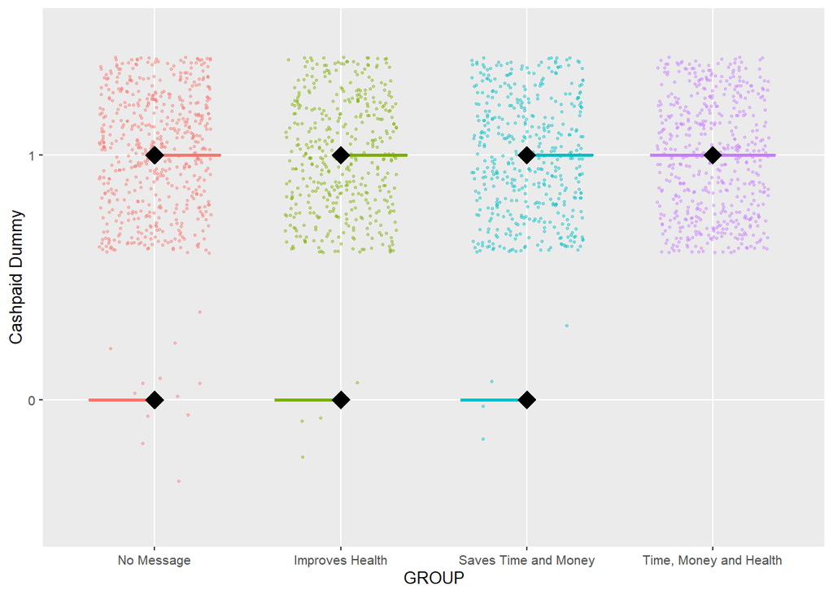

```r
### Visualization
ggplot(data, aes(GROUP, CASHPAID_Dummy, color=GROUP)) +
  geom_boxplot(show.legend=FALSE, outlier.shape = NA) +
  geom_jitter(width=0.3, alpha = 0.4, size=0.5, show.legend=FALSE) +
  ylab(label = "Cashpaid Dummy") +
  stat_summary(fun = "mean", size = 5, geom = "point", shape=18, color = 'black') +
  geom_hline(yintercept = 0) +
  theme_grey(base_size=10)
```

```r
### Krusal-Wallis test
kruskal.test(CASHPAID_Dummy ~ GROUP, data )
```

```
##
##  Kruskal-Wallis rank sum test
##
## data:  CASHPAID_Dummy by GROUP
## Kruskal-Wallis chi-squared = 12.741, df = 3, p-value = 0.005231
```

### 2.2.2 Wealth variables - W

We ignore SPOUSE phone since there are 473 missing values (about 20% of whole data set).

1. HH_PHONES - Count of phones owned by household

```r
### Summary
data=Data[!is.na(Data$HH_PHONES ), ]
data$GROUP<- factor(data$GROUP, levels = c("No Message", "Improves Health", "Saves Time and Money","Time, Money and Health" ))
HH_PHONES_mean <- tapply(as.numeric(data$HH_PHONES), data$GROUP, mean)
HH_PHONES_sd <- tapply(as.numeric((data$HH_PHONES)), data$GROUP, sd)
n <- tapply(data$HH_PHONES, data$GROUP, length)
data.frame(mean = HH_PHONES_mean, std.dev = HH_PHONES_sd, n = n)
```

```
##                             mean   std.dev   n
## No Message             0.9388112 0.7258770 572
## Improves Health        0.8360360 0.6500198 555
## Saves Time and Money   0.7340619 0.6088955 549
## Time, Money and Health 0.9749104 0.6931943 558
```

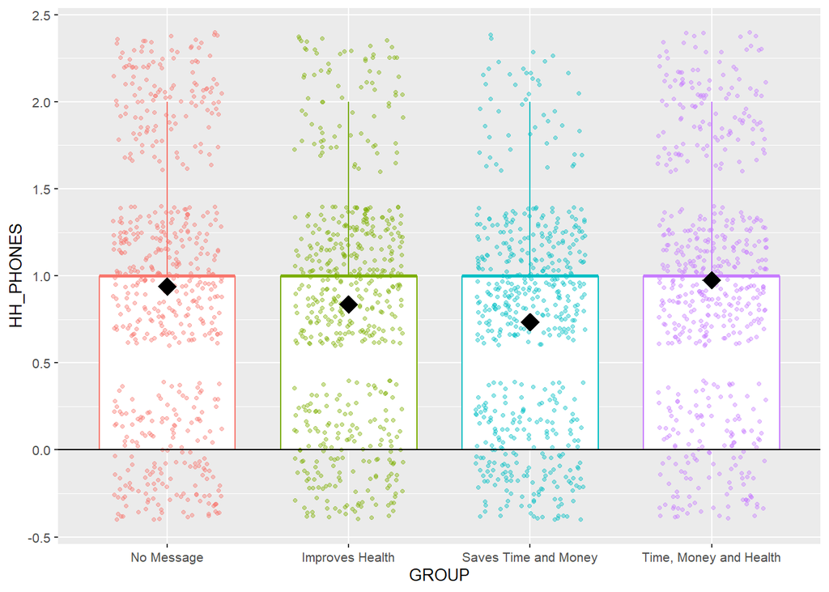

```r
### Visualization
ggplot(data, aes(GROUP, HH_PHONES, color=GROUP)) +
  geom_boxplot(show.legend=FALSE, outlier.shape = NA) +
  geom_jitter(width=0.3, alpha = 0.4, size=0.9, show.legend=FALSE) +
  ylab(label = "HH_PHONES") +
  stat_summary(fun = "mean", size = 5, geom = "point", shape=18, color = 'black') +
  geom_hline(yintercept = 0) +
  theme_grey(base_size=10)
```

```r
### Krusal-Wallis test
kruskal.test(HH_PHONES ~ GROUP, data )
```

```
##
##  Kruskal-Wallis rank sum test
##
## data:  HH_PHONES by GROUP
## Kruskal-Wallis chi-squared = 39.642, df = 3, p-value = 1.269e-08
```

2. INCOME - Earns income

```r
### Create INCOME_Dummy
data=Data[!is.na(Data$INCOME), ]
data$INCOME_Dummy = data$INCOME
data$INCOME_Dummy[data$INCOME_Dummy != "Yes"] <- 0
data$INCOME_Dummy[data$INCOME_Dummy == "Yes"] <- 1
data_plus$INCOME_Dummy = data$INCOME_Dummy

### Summary
data$GROUP<- factor(data$GROUP, levels = c("No Message", "Improves Health", "Saves Time and Money","Time, Money and Health" ))
Income_mean <- tapply(as.numeric(data$INCOME_Dummy), data$GROUP, mean)
Income_sd <- tapply(as.numeric((data$INCOME_Dummy)), data$GROUP, sd)
n <- tapply(data$INCOME_Dummy, data$GROUP, length)
data.frame(mean = Income_mean, std.dev = Income_sd, n = n)
```

```
##                             mean   std.dev   n
## No Message             0.9631579 0.1885395 570
## Improves Health        0.7783784 0.4157125 555
## Saves Time and Money   0.8296703 0.3762669 546
## Time, Money and Health 0.9228007 0.2671473 557
```

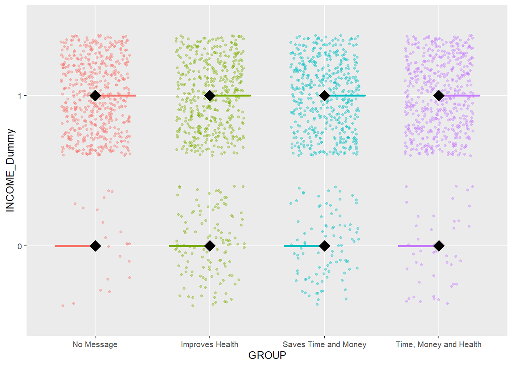

```r
### Visualization
ggplot(data, aes(GROUP, INCOME_Dummy, color=GROUP)) +
  geom_boxplot(show.legend=FALSE, outlier.shape = NA) +
  geom_jitter(width=0.3, alpha = 0.4, size=0.9, show.legend=FALSE) +
  ylab(label = "INCOME_Dummy") +
  stat_summary(fun = "mean", size = 5, geom = "point", shape=18, color = 'black') +
  geom_hline(yintercept = 0) +
  theme_grey(base_size=10)
```

```r
### Krusal-Wallis test
kruskal.test(INCOME_Dummy ~ GROUP, data )
```

```
##
##  Kruskal-Wallis rank sum test
##
## data:  INCOME_Dummy by GROUP
## Kruskal-Wallis chi-squared = 109.21, df = 3, p-value < 2.2e-16
```

3. VEHICLE1 (BICYCLE_DUMMY, CAR_DUMMY, MOTORCYCLE_DUMMY)

```r
### Summary
data$GROUP<- factor(data$GROUP, levels = c("No Message", "Improves Health", "Saves Time and Money","Time, Money and Health" ))
BICYCLE_DUMMY_mean <- tapply(as.numeric(data$BICYCLE_DUMMY ), data$GROUP, mean)
BICYCLE_DUMMY_sd <- tapply(as.numeric((data$BICYCLE_DUMMY )), data$GROUP, sd)
n <- tapply(data$BICYCLE_DUMMY , data$GROUP, length)
data.frame(mean = BICYCLE_DUMMY_mean, std.dev = BICYCLE_DUMMY_sd, n = n)
```

```
##                             mean   std.dev   n
## No Message             0.4929825 0.5003899 570
## Improves Health        0.4972973 0.5004437 555
## Saves Time and Money   0.5054945 0.5004283 546
## Time, Money and Health 0.4649910 0.4992212 557
```

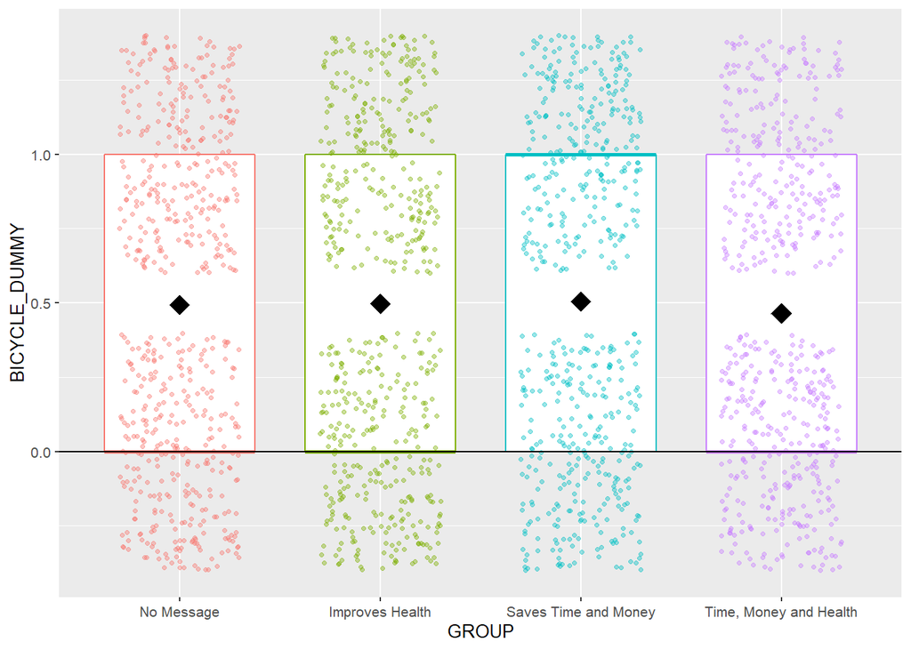

```r
### Visualization
ggplot(data, aes(GROUP, BICYCLE_DUMMY, color=GROUP)) +
  geom_boxplot(show.legend=FALSE, outlier.shape = NA) +
  geom_jitter(width=0.3, alpha = 0.4, size=0.9, show.legend=FALSE) +
  ylab(label = "BICYCLE_DUMMY") +
  stat_summary(fun = "mean", size = 5, geom = "point", shape=18, color = 'black') +
  geom_hline(yintercept = 0) +
  theme_grey(base_size=10)
```

```r
### Krusal-Wallis test
kruskal.test(BICYCLE_DUMMY ~ GROUP, data )
```

```
##
##  Kruskal-Wallis rank sum test
##
## data:  BICYCLE_DUMMY by GROUP
## Kruskal-Wallis chi-squared = 2.0561, df = 3, p-value = 0.5609
```

```r
######################################################################
### Summary
data$GROUP<- factor(data$GROUP, levels = c("No Message", "Improves Health", "Saves Time and Money","Time, Money and Health" ))
CAR_DUMMY_mean <- tapply(as.numeric(data$CAR_DUMMY ), data$GROUP, mean)
CAR_DUMMY_sd <- tapply(as.numeric((data$CAR_DUMMY )), data$GROUP, sd)
n <- tapply(data$CAR_DUMMY , data$GROUP, length)
data.frame(mean = CAR_DUMMY_mean, std.dev = CAR_DUMMY_sd, n = n)
```

```
##                               mean   std.dev   n
## No Message             0.014035088 0.1177388 570
## Improves Health        0.012612613 0.1116961 555
## Saves Time and Money   0.005494505 0.0739888 546
## Time, Money and Health 0.028725314 0.1671836 557
```

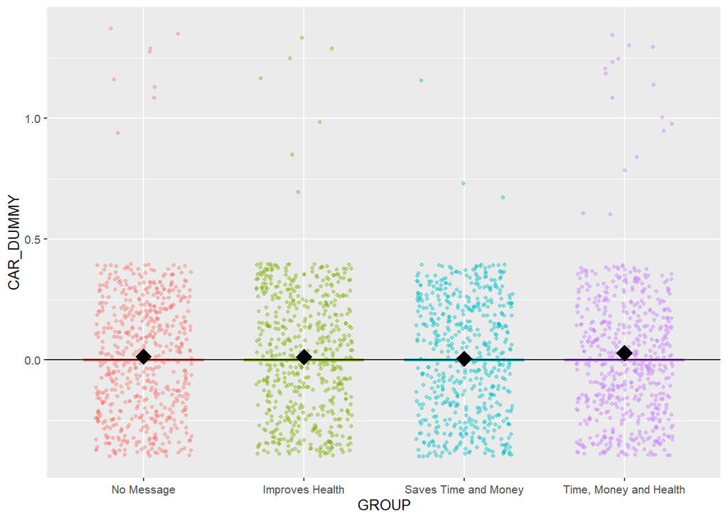

```r
### Visualization
ggplot(data, aes(GROUP, CAR_DUMMY, color=GROUP)) +
  geom_boxplot(show.legend=FALSE, outlier.shape = NA) +
  geom_jitter(width=0.3, alpha = 0.4, size=0.9, show.legend=FALSE) +
  ylab(label = "CAR_DUMMY") +
  stat_summary(fun = "mean", size = 5, geom = "point", shape=18, color = 'black') +
  geom_hline(yintercept = 0) +
  theme_grey(base_size=10)
```

```r
### Krusal-Wallis test
kruskal.test(CAR_DUMMY ~ GROUP, data )
```

```
##
##  Kruskal-Wallis rank sum test
##
## data:  CAR_DUMMY by GROUP
## Kruskal-Wallis chi-squared = 10.497, df = 3, p-value = 0.01478
```

```r
#######################################################################
### Summary
data$GROUP<- factor(data$GROUP, levels = c("No Message", "Improves Health", "Saves Time and Money","Time, Money and Health" ))
MOTORCYCLE_DUMMY_mean <- tapply(as.numeric(data$MOTORCYCLE_DUMMY ), data$GROUP, mean)
MOTORCYCLE_DUMMY_sd <- tapply(as.numeric((data$MOTORCYCLE_DUMMY )), data$GROUP, sd)
n <- tapply(data$MOTORCYCLE_DUMMY , data$GROUP, length)
data.frame(mean = MOTORCYCLE_DUMMY_mean, std.dev = MOTORCYCLE_DUMMY_sd, n = n)
```

```
##                              mean   std.dev   n
## No Message             0.12631579 0.3324967 570
## Improves Health        0.10630631 0.3085073 555
## Saves Time and Money   0.08058608 0.2724480 546
## Time, Money and Health 0.11490126 0.3191894 557
```

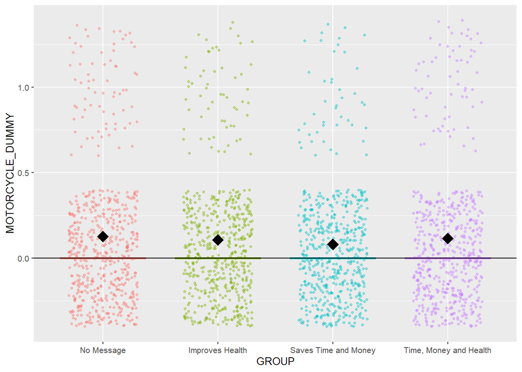

```r
### Visualization
ggplot(data, aes(GROUP, MOTORCYCLE_DUMMY, color=GROUP)) +
  geom_boxplot(show.legend=FALSE, outlier.shape = NA) +
  geom_jitter(width=0.3, alpha = 0.4, size=0.9, show.legend=FALSE) +
  ylab(label = "MOTORCYCLE_DUMMY") +
  stat_summary(fun = "mean", size = 5, geom = "point", shape=18, color = 'black') +
  geom_hline(yintercept = 0) +
  theme_grey(base_size=10)
```

```r
### Krusal-Wallis test
kruskal.test(MOTORCYCLE_DUMMY ~ GROUP, data )
```

```
##
##  Kruskal-Wallis rank sum test
##
## data:  MOTORCYCLE_DUMMY by GROUP
## Kruskal-Wallis chi-squared = 6.5599, df = 3, p-value = 0.08733
```

4. RADIO_DUMMY

```r
### Summary
data$GROUP<- factor(data$GROUP, levels = c("No Message", "Improves Health", "Saves Time and Money","Time, Money and Health" ))
RADIO_DUMMY_mean <- tapply(as.numeric(data$RADIO_DUMMY ), data$GROUP, mean)
RADIO_DUMMY_sd <- tapply(as.numeric((data$RADIO_DUMMY )), data$GROUP, sd)
n <- tapply(data$RADIO_DUMMY , data$GROUP, length)
data.frame(mean = RADIO_DUMMY_mean, std.dev = RADIO_DUMMY_sd, n = n)
```

```
##                             mean   std.dev   n
## No Message             0.9070175 0.2906629 570
## Improves Health        0.8972973 0.3038440 555
## Saves Time and Money   0.8717949 0.3346246 546
## Time, Money and Health 0.8797127 0.3255895 557
```

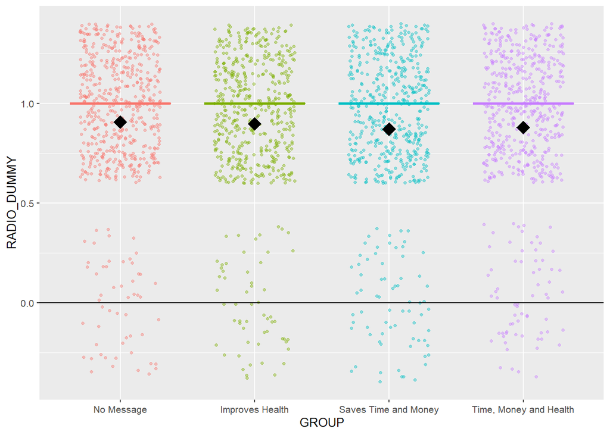

```r
### Visualization
ggplot(data, aes(GROUP, RADIO_DUMMY, color=GROUP)) +
  geom_boxplot(show.legend=FALSE, outlier.shape = NA) +
  geom_jitter(width=0.3, alpha = 0.4, size=0.9, show.legend=FALSE) +
  ylab(label = "RADIO_DUMMY") +
  stat_summary(fun = "mean", size = 5, geom = "point", shape=18, color = 'black') +
  geom_hline(yintercept = 0) +
  theme_grey(base_size=10)
```

```r
### Krusal-Wallis test
kruskal.test(RADIO_DUMMY ~ GROUP, data )
```

```
##
##  Kruskal-Wallis rank sum test
##
## data:  RADIO_DUMMY by GROUP
## Kruskal-Wallis chi-squared = 4.3895, df = 3, p-value = 0.2224
```

5. SELFEMPLOYED - Visualization on MAINEMPLOYER, test on SELFEMPLOYED

```r
### Summary
data=Data[!is.na(Data$SELFEMPLOYED ), ]
data$GROUP<- factor(data$GROUP, levels = c("No Message", "Improves Health", "Saves Time and Money","Time, Money and Health" ))
SELFEMPLOYED_mean <- tapply(as.numeric(data$SELFEMPLOYED ), data$GROUP, mean)
SELFEMPLOYED_sd <- tapply(as.numeric((data$SELFEMPLOYED )), data$GROUP, sd)
n <- tapply(data$SELFEMPLOYED , data$GROUP, length)
data.frame(mean = SELFEMPLOYED_mean, std.dev = SELFEMPLOYED_sd, n = n)
```

```
##                             mean   std.dev   n
## No Message             0.8444056 0.3627877 572
## Improves Health        0.5531532 0.4976152 555
## Saves Time and Money   0.5974499 0.4908588 549
## Time, Money and Health 0.7168459 0.4509349 558
```

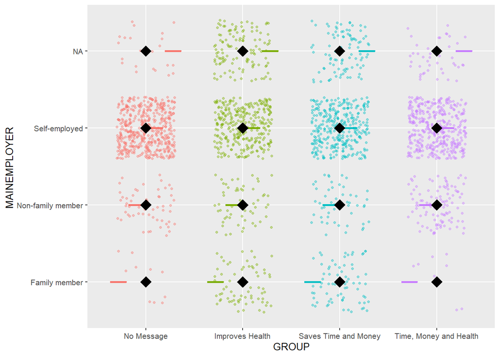

```r
### Visualization
ggplot(data, aes(GROUP, MAINEMPLOYER , color=GROUP)) +
  geom_boxplot(show.legend=FALSE, outlier.shape = NA) +
  geom_jitter(width=0.3, alpha = 0.4, size=0.9, show.legend=FALSE) +
  ylab(label = "MAINEMPLOYER ") +
  stat_summary(fun = "mean", size = 5, geom = "point", shape=18, color = 'black') +
  geom_hline(yintercept = 0) +
  theme_grey(base_size=10)
```

```r
### Krusal-Wallis test
kruskal.test(SELFEMPLOYED ~ GROUP, data )
```

```
##
##  Kruskal-Wallis rank sum test
##
## data:  SELFEMPLOYED by GROUP
## Kruskal-Wallis chi-squared = 132.59, df = 3, p-value < 2.2e-16
```

6. TIME_EMPLOYED - Year round employment (share)

```r
### Summary
data=Data[!is.na(Data$TIME_EMPLOYED ), ]
data$GROUP<- factor(data$GROUP, levels = c("No Message", "Improves Health", "Saves Time and Money","Time, Money and Health" ))
TIME_EMPLOYED_mean <- tapply(as.numeric(data$TIME_EMPLOYED ), data$GROUP, mean)
TIME_EMPLOYED_sd <- tapply(as.numeric((data$TIME_EMPLOYED)), data$GROUP, sd)
n <- tapply(data$TIME_EMPLOYED , data$GROUP, length)
data.frame(mean =TIME_EMPLOYED_mean, std.dev = TIME_EMPLOYED_sd, n = n)
```

```
##                             mean   std.dev   n
## No Message             0.5069930 0.5003887 572
## Improves Health        0.5189189 0.5000927 555
## Saves Time and Money   0.4499089 0.4979383 549
## Time, Money and Health 0.7096774 0.4543185 558
```

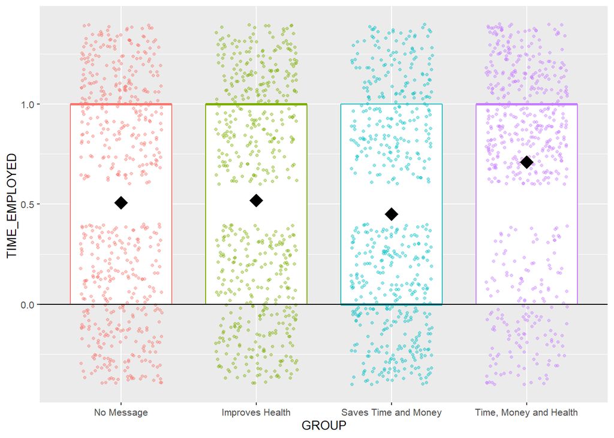

```r
### Visualization
ggplot(data, aes(GROUP,TIME_EMPLOYED , color=GROUP)) +
  geom_boxplot(show.legend=FALSE, outlier.shape = NA) +
  geom_jitter(width=0.3, alpha = 0.4, size=0.9, show.legend=FALSE) +
  ylab(label = "TIME_EMPLOYED ") +
  stat_summary(fun = "mean", size = 5, geom = "point", shape=18, color = 'black') +
  geom_hline(yintercept = 0) +
  theme_grey(base_size=10)
```

```r
### Krusal-Wallis test
kruskal.test(TIME_EMPLOYED ~ GROUP, data )
```

```
##
##  Kruskal-Wallis rank sum test
##
## data:  TIME_EMPLOYED by GROUP
## Kruskal-Wallis chi-squared = 85.886, df = 3, p-value < 2.2e-16
```

7. COWS

```r
### Create COWS_Dummy
data=Data[!is.na(Data$COWS), ]
data$COWS_Dummy = data$COWS
data$COWS_Dummy[data$COWS_Dummy == "No"] <- 0
data$COWS_Dummy[data$COWS_Dummy == "Yes"] <- 1
data_plus$COWS_Dummy = data$COWS_Dummy

### Summary
data$GROUP<- factor(data$GROUP, levels = c("No Message", "Improves Health", "Saves Time and Money","Time, Money and Health" ))
COWS_Dummy_mean <- tapply(as.numeric(data$COWS_Dummy ), data$GROUP, mean)
COWS_Dummy_sd <- tapply(as.numeric((data$COWS_Dummy)), data$GROUP, sd)
n <- tapply(data$COWS_Dummy , data$GROUP, length)
data.frame(mean =COWS_Dummy_mean, std.dev =COWS_Dummy_sd, n = n)
```

```
##                             mean   std.dev   n
## No Message             0.3070175 0.4616619 570
## Improves Health        0.3153153 0.4650605 555
## Saves Time and Money   0.2655678 0.4420400 546
## Time, Money and Health 0.2818671 0.4503134 557
```

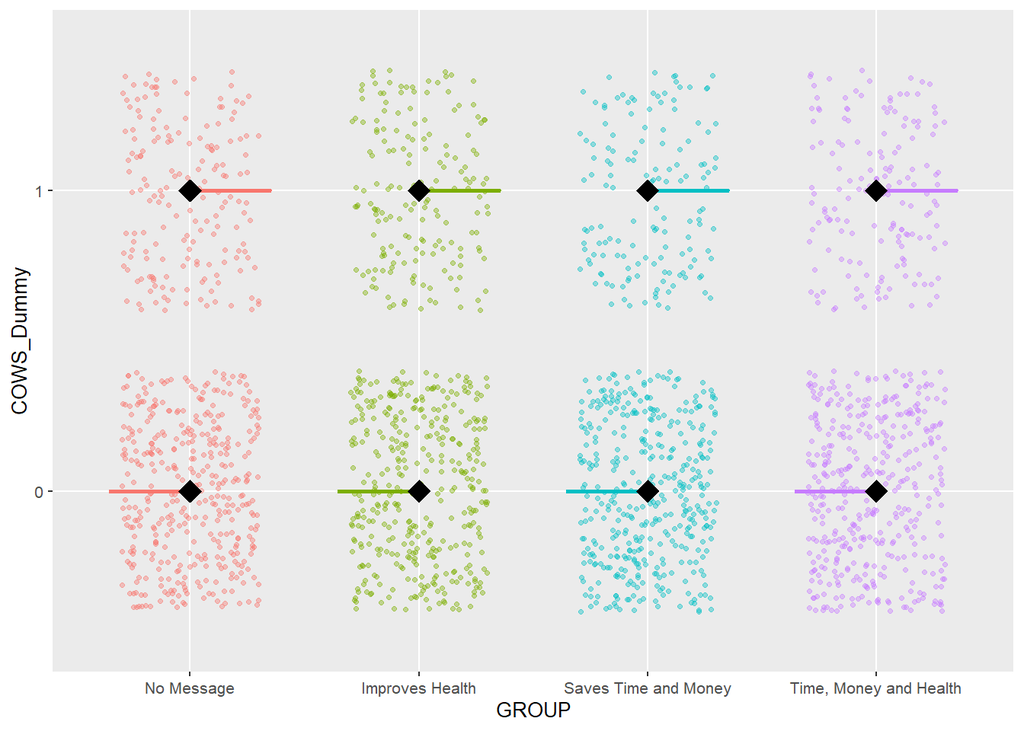

```r
### Visualization
ggplot(data, aes(GROUP,COWS_Dummy, color=GROUP)) +
  geom_boxplot(show.legend=FALSE, outlier.shape = NA) +
  geom_jitter(width=0.3, alpha = 0.4, size=0.9, show.legend=FALSE) +
  ylab(label = "COWS_Dummy") +
  stat_summary(fun = "mean", size = 5, geom = "point", shape=18, color = 'black') +
  geom_hline(yintercept = 0) +
  theme_grey(base_size=10)
```

```r
### Krusal-Wallis test
kruskal.test(COWS_Dummy~ GROUP, data )
```

```
##
##  Kruskal-Wallis rank sum test
##
## data:  COWS_Dummy by GROUP
## Kruskal-Wallis chi-squared = 4.1913, df = 3, p-value = 0.2415
```

8. TV

```r
### Create TV_Dummy
data$TV_Dummy = data$TV
data$TV_Dummy[data$TV_Dummy == "No"] <- 0
data$TV_Dummy[is.na(data$TV_Dummy)] <- 0
data$TV_Dummy[data$TV_Dummy == "Yes"] <- 1
data_plus$TV_Dummy = data$TV_Dummy

### Summary
data$GROUP<- factor(data$GROUP, levels = c("No Message", "Improves Health", "Saves Time and Money","Time, Money and Health" ))
TV_Dummy_mean <- tapply(as.numeric(data$TV_Dummy ), data$GROUP, mean)
TV_Dummy_sd <- tapply(as.numeric((data$TV_Dummy)), data$GROUP, sd)
n <- tapply(data$TV_Dummy , data$GROUP, length)
data.frame(mean =TV_Dummy_mean, std.dev =TV_Dummy_sd, n = n)
```

```
##                              mean   std.dev   n
## No Message             0.05789474 0.2337494 570
## Improves Health        0.05585586 0.2298503 555
## Saves Time and Money   0.02564103 0.1582068 546
## Time, Money and Health 0.06283662 0.2428870 557
```

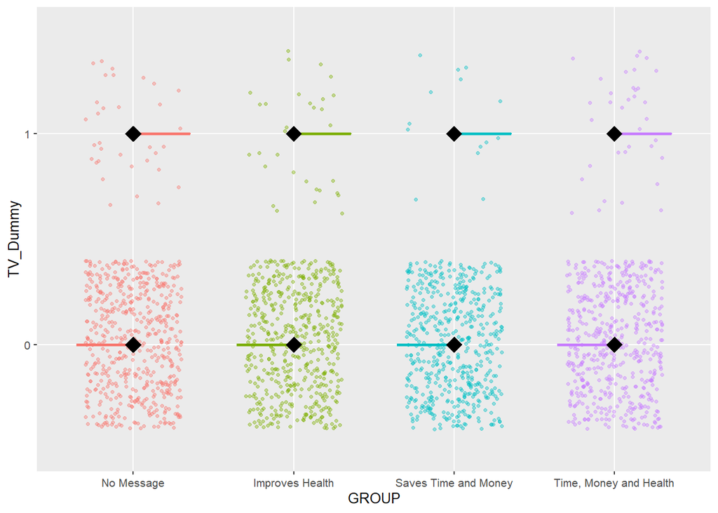

```r
### Visualization
ggplot(data, aes(GROUP,TV_Dummy, color=GROUP)) +
  geom_boxplot(show.legend=FALSE, outlier.shape = NA) +
  geom_jitter(width=0.3, alpha = 0.4, size=0.9, show.legend=FALSE) +
  ylab(label = "TV_Dummy") +
  stat_summary(fun = "mean", size = 5, geom = "point", shape=18, color = 'black') +
  geom_hline(yintercept = 0) +
  theme_grey(base_size=10)
```

```r
### Krusal-Wallis test
kruskal.test(TV_Dummy~ GROUP, data )
```

```
##
##  Kruskal-Wallis rank sum test
##
## data:  TV_Dummy by GROUP
## Kruskal-Wallis chi-squared = 9.7403, df = 3, p-value = 0.02091
```

9. *Total_Asset - this is computed with all the wealth dummies and durable good prices provided.*

```r
### Create TV_Dummy
ASSET_TOTAL = read.csv("ASSET_VALUE.csv")
data_plus$ASSET_TOTAL = ASSET_TOTAL$ASSET
data = data_plus

### Summary
data$GROUP<- factor(data$GROUP, levels = c("No Message", "Improves Health", "Saves Time and Money","Time, Money and Health" ))

ASSET_TOTAL_mean <- tapply(data$ASSET_TOTAL, data$GROUP, mean)
ASSET_TOTAL_sd <- tapply(as.numeric((data$ASSET_TOTAL)), data$GROUP, sd)
n <- tapply(data$ASSET_TOTAL , data$GROUP, length)
data.frame(mean =ASSET_TOTAL_mean, std.dev =ASSET_TOTAL_sd, n = n)
```

```
##                            mean   std.dev   n
## No Message             630.0371 1130.5497 570
## Improves Health        602.1494 1088.7792 555
## Saves Time and Money   476.5693  881.9233 546
## Time, Money and Health 647.8504 1242.0216 557
```

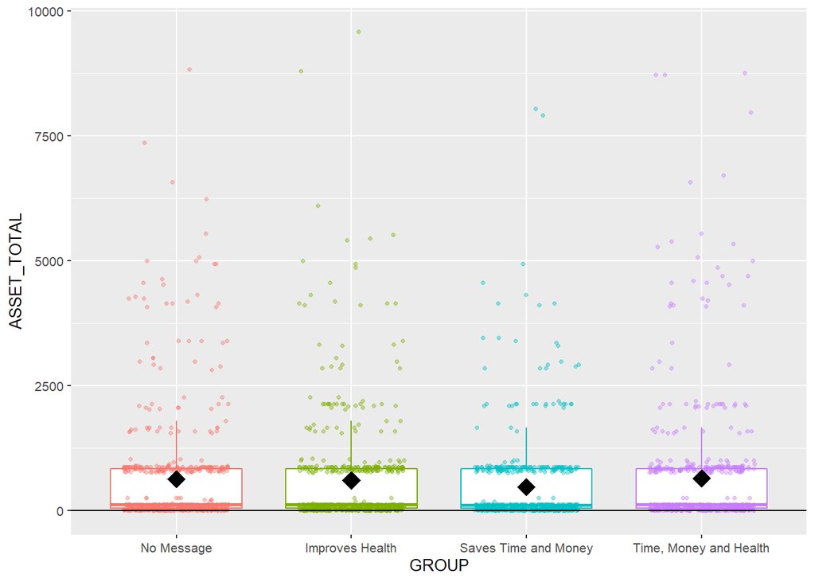

```r
### Visualization
ggplot(data, aes(GROUP,ASSET_TOTAL, color=GROUP)) +
  geom_boxplot(show.legend=FALSE, outlier.shape = NA) +
  geom_jitter(width=0.3, alpha = 0.4, size=0.9, show.legend=FALSE) +
  ylab(label = "ASSET_TOTAL") +
  stat_summary(fun = "mean", size = 5, geom = "point", shape=18, color = 'black') +
  geom_hline(yintercept = 0) +
  theme_grey(base_size=10)
```

```r
### Krusal-Wallis test
kruskal.test(ASSET_TOTAL~ GROUP, data )
```

```
##
##  Kruskal-Wallis rank sum test
##
## data:  ASSET_TOTAL by GROUP
## Kruskal-Wallis chi-squared = 4.966, df = 3, p-value = 0.1743
```

### 2.2.3 Cookstove variables - C

1.WOOD - the dummy of whether wood is the primary fuel.

```r
### Summary
data=Data[!is.na(Data$WOOD ), ]
data$GROUP<- factor(data$GROUP, levels = c("No Message", "Improves Health", "Saves Time and Money","Time, Money and Health" ))
WOOD_mean <- tapply(as.numeric(data$WOOD), data$GROUP, mean)
WOOD_sd <- tapply(as.numeric((data$WOOD)), data$GROUP, sd)
n <- tapply(data$WOOD, data$GROUP, length)
data.frame(mean = WOOD_mean, std.dev = WOOD_sd, n = n)
```

```
##                             mean   std.dev   n
## No Message             0.9737762 0.1599400 572
## Improves Health        0.9927928 0.0846651 555
## Saves Time and Money   0.9526412 0.2125989 549
## Time, Money and Health 0.9659498 0.1815208 558
```

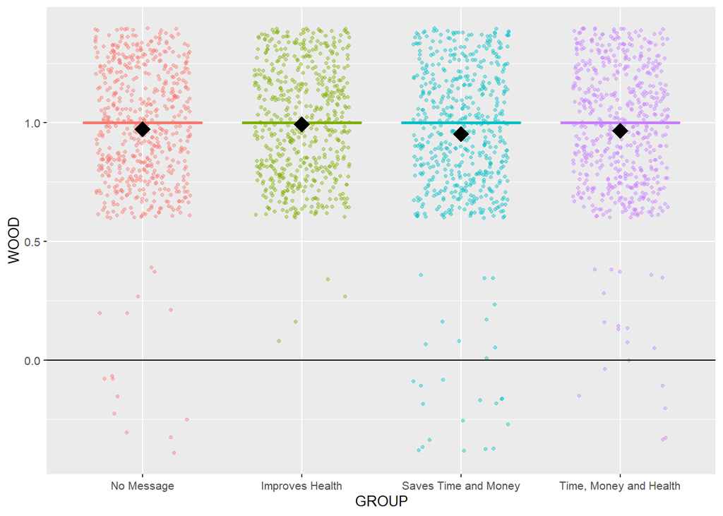

```r
### Visualization
ggplot(data, aes(GROUP, WOOD, color=GROUP)) +
  geom_boxplot(show.legend=FALSE, outlier.shape = NA) +
  geom_jitter(width=0.3, alpha = 0.4, size=0.9, show.legend=FALSE) +
  ylab(label = "WOOD") +
  stat_summary(fun = "mean", size = 5, geom = "point", shape=18, color = 'black') +
  geom_hline(yintercept = 0) +
  theme_grey(base_size=10)
```

```r
### Krusal-Wallis test
kruskal.test(WOOD ~ GROUP, data )
```

```
##
##  Kruskal-Wallis rank sum test
##
## data:  WOOD by GROUP
## Kruskal-Wallis chi-squared = 16.774, df = 3, p-value = 0.0007866
```

2. TSF_PRIMARY - whether a three-stone fire is the primary stove. None means owning a stone stove. Test on TSF_PRIMARY, visualization on STOVES1.

```r
### Summary
data=Data[!is.na(Data$STOVES1 ), ]
data$GROUP<- factor(data$GROUP, levels = c("No Message", "Improves Health", "Saves Time and Money","Time, Money and Health" ))
TSF_PRIMARY_mean <- tapply(as.numeric(data$TSF_PRIMARY), data$GROUP, mean)
TSF_PRIMARY_sd <- tapply(as.numeric((data$TSF_PRIMARY)), data$GROUP, sd)
n <- tapply(data$TSF_PRIMARY, data$GROUP, length)
data.frame(mean = TSF_PRIMARY_mean, std.dev = TSF_PRIMARY_sd, n = n)
```

```
##                             mean   std.dev   n
## No Message             0.6964912 0.4601768 570
## Improves Health        0.7783784 0.4157125 555
## Saves Time and Money   0.7637363 0.4251756 546
## Time, Money and Health 0.6858169 0.4646070 557
```

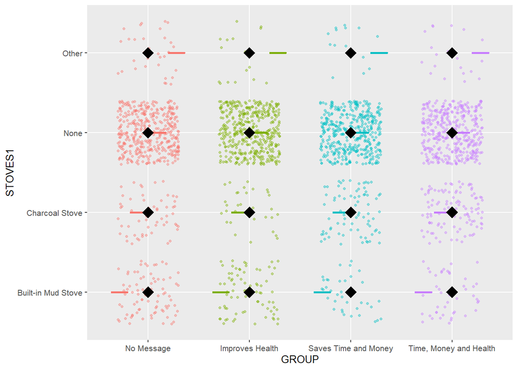

```r
### Visualization
ggplot(data, aes(GROUP, STOVES1, color=GROUP)) +
  geom_boxplot(show.legend=FALSE, outlier.shape = NA) +
  geom_jitter(width=0.3, alpha = 0.4, size=0.9, show.legend=FALSE) +
  ylab(label = "STOVES1") +
  stat_summary(fun = "mean", size = 5, geom = "point", shape=18, color = 'black') +
  geom_hline(yintercept = 0) +
  theme_grey(base_size=10)
```

```r
### Krusal-Wallis test
kruskal.test(TSF_PRIMARY ~ GROUP, data )
```

```
##
##  Kruskal-Wallis rank sum test
##
## data:  TSF_PRIMARY by GROUP
## Kruskal-Wallis chi-squared = 18.524, df = 3, p-value = 0.000343
```

3. BUYWOOD_DUMMY- buys wood last week or month

```r
### Summary
data=Data[!is.na(Data$BUYWOOD_DUMMY ), ]
data$GROUP<- factor(data$GROUP, levels = c("No Message", "Improves Health", "Saves Time and Money","Time, Money and Health" ))
BUYWOOD_DUMMY_mean <- tapply(as.numeric(data$BUYWOOD_DUMMY), data$GROUP, mean)
BUYWOOD_DUMMY_sd <- tapply(as.numeric((data$BUYWOOD_DUMMY)), data$GROUP, sd)
n <- tapply(data$BUYWOOD_DUMMY, data$GROUP, length)
data.frame(mean = BUYWOOD_DUMMY_mean, std.dev = BUYWOOD_DUMMY_sd, n = n)
```

```
##                             mean   std.dev   n
## No Message             0.2982456 0.4578897 570
## Improves Health        0.2504505 0.4336633 555
## Saves Time and Money   0.3296703 0.4705245 546
## Time, Money and Health 0.3213645 0.4674201 557
```

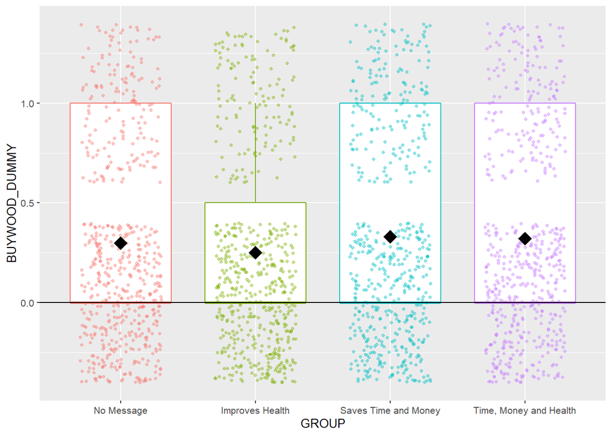

```r
### Visualization
ggplot(data, aes(GROUP, BUYWOOD_DUMMY, color=GROUP)) +
  geom_boxplot(show.legend=FALSE, outlier.shape = NA) +
  geom_jitter(width=0.3, alpha = 0.4, size=0.9, show.legend=FALSE) +
  ylab(label = "BUYWOOD_DUMMY") +
  stat_summary(fun = "mean", size = 5, geom = "point", shape=18, color = 'black') +
  geom_hline(yintercept = 0) +
  theme_grey(base_size=10)
```

```r
### Krusal-Wallis test
kruskal.test(BUYWOOD_DUMMY ~ GROUP, data )
```

```
##
##  Kruskal-Wallis rank sum test
##
## data:  BUYWOOD_DUMMY by GROUP
## Kruskal-Wallis chi-squared = 9.9951, df = 3, p-value = 0.01861
```

4. GATHERWOOD_DUMMY - whether the household gathered wood last week

```r
### Summary
data=Data[!is.na(Data$GATHERWOOD_DUMMY ), ]
data$GROUP<- factor(data$GROUP, levels = c("No Message", "Improves Health", "Saves Time and Money","Time, Money and Health" ))
GATHERWOOD_DUMMY_mean <- tapply(as.numeric(data$GATHERWOOD_DUMMY), data$GROUP, mean)
GATHERWOOD_DUMMY_sd <- tapply(as.numeric((data$GATHERWOOD_DUMMY)), data$GROUP, sd)
n <- tapply(data$GATHERWOOD_DUMMY, data$GROUP, length)
data.frame(mean = GATHERWOOD_DUMMY_mean, std.dev = GATHERWOOD_DUMMY_sd, n = n)
```

```
##                             mean   std.dev   n
## No Message             0.8684211 0.3383293 570
## Improves Health        0.8828829 0.3218499 555
## Saves Time and Money   0.8974359 0.3036669 546
## Time, Money and Health 0.8868941 0.3170069 557
```

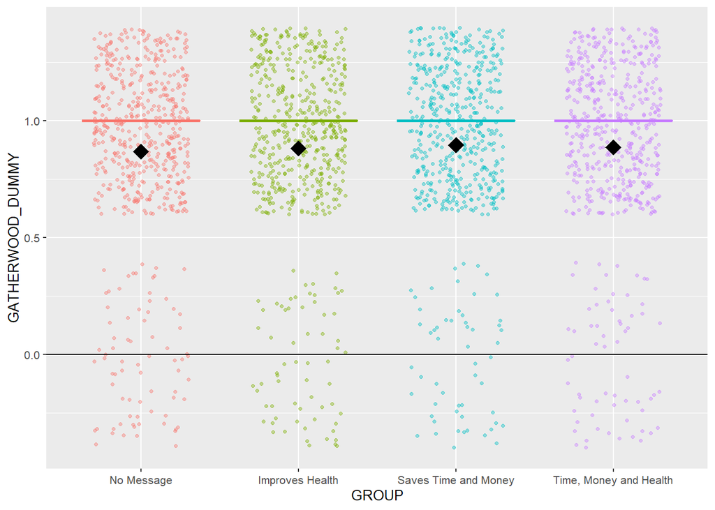

```r
### Visualization
ggplot(data, aes(GROUP, GATHERWOOD_DUMMY, color=GROUP)) +
  geom_boxplot(show.legend=FALSE, outlier.shape = NA) +
  geom_jitter(width=0.3, alpha = 0.4, size=0.9, show.legend=FALSE) +
  ylab(label = "GATHERWOOD_DUMMY") +
  stat_summary(fun = "mean", size = 5, geom = "point", shape=18, color = 'black') +
  geom_hline(yintercept = 0) +
  theme_grey(base_size=10)
```

```r
### Krusal-Wallis test
kruskal.test(GATHERWOOD_DUMMY ~ GROUP, data )
```

```
##
##  Kruskal-Wallis rank sum test
##
## data:  GATHERWOOD_DUMMY by GROUP
## Kruskal-Wallis chi-squared = 2.3558, df = 3, p-value = 0.5019
```

### 2.2.4 Dependent variables - Y

*1. MAXBID*

```r
### Summary
data=Data[!is.na(Data$MAXBID ), ]
data$GROUP<- factor(data$GROUP, levels = c("No Message", "Improves Health", "Saves Time and Money","Time, Money and Health" ))
MAXBID_mean <- tapply(as.numeric(data$MAXBID), data$GROUP, mean)
MAXBID_sd <- tapply(as.numeric((data$MAXBID)), data$GROUP, sd)
n <- tapply(data$MAXBID, data$GROUP, length)
data.frame(mean = MAXBID_mean, std.dev = MAXBID_sd, n = n)
```

```
##                            mean  std.dev   n
## No Message             4.579009 4.819203 546
## Improves Health        5.503134 5.220355 525
## Saves Time and Money   4.474517 4.135269 513
## Time, Money and Health 4.877390 4.281005 541
```

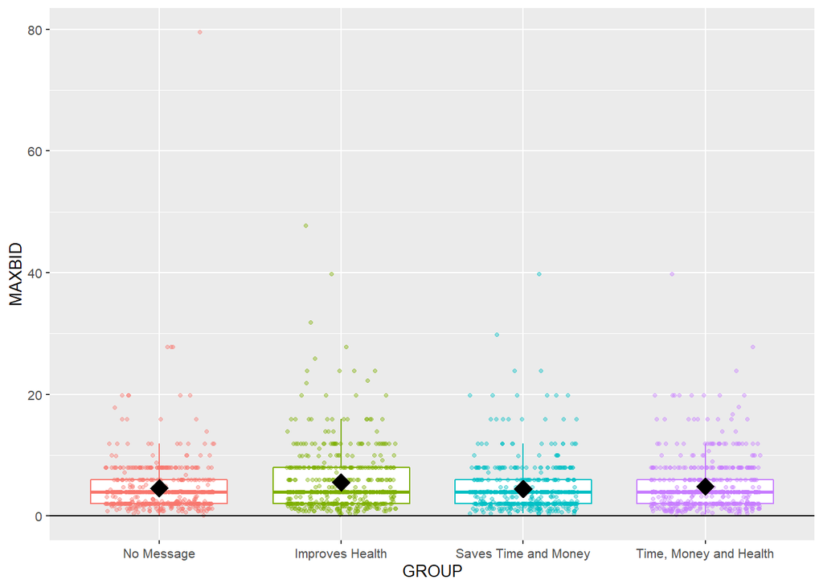

```r
### Visualization
ggplot(data, aes(GROUP, MAXBID, color=GROUP)) +
  geom_boxplot(show.legend=FALSE, outlier.shape = NA) +
  geom_jitter(width=0.3, alpha = 0.4, size=0.9, show.legend=FALSE) +
  ylab(label = "MAXBID") +
  stat_summary(fun = "mean", size = 5, geom = "point", shape=18, color = 'black') +
  geom_hline(yintercept = 0) +
  theme_grey(base_size=10)
```

```r
### Krusal-Wallis test
kruskal.test(MAXBID ~ GROUP, data )
```

```
##
##  Kruskal-Wallis rank sum test
##
## data:  MAXBID by GROUP
## Kruskal-Wallis chi-squared = 11.644, df = 3, p-value = 0.008708
```

*2. MAXBIDNOVEL*

```r
### Summary
data=Data[!is.na(Data$MAXBIDNOVEL ), ]
data$GROUP<- factor(data$GROUP, levels = c("No Message", "Improves Health", "Saves Time and Money","Time, Money and Health" ))
MAXBIDNOVEL_mean <- tapply(as.numeric(data$MAXBIDNOVEL), data$GROUP, mean)
MAXBIDNOVEL_sd <- tapply(as.numeric((data$MAXBIDNOVEL)), data$GROUP, sd)
n <- tapply(data$MAXBIDNOVEL, data$GROUP, length)
data.frame(mean = MAXBIDNOVEL_mean, std.dev = MAXBIDNOVEL_sd, n = n)
```

```
##                            mean std.dev   n
## No Message             6.732729 6.87404 544
## Improves Health        6.815442 6.34957 514
## Saves Time and Money   7.171327 6.37634 535
## Time, Money and Health 6.608321 5.90320 542
```

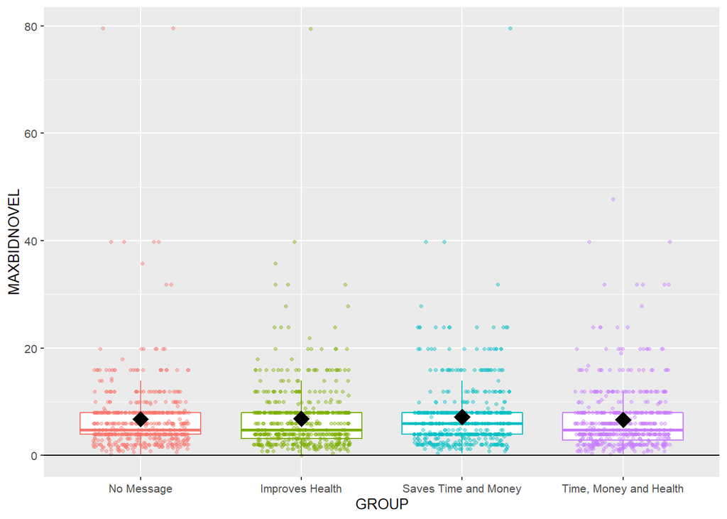

```r
### Visualization
ggplot(data, aes(GROUP, MAXBIDNOVEL, color=GROUP)) +
  geom_boxplot(show.legend=FALSE, outlier.shape = NA) +
  geom_jitter(width=0.3, alpha = 0.4, size=0.9, show.legend=FALSE) +
  ylab(label = "MAXBIDNOVEL") +
  stat_summary(fun = "mean", size = 5, geom = "point", shape=18, color = 'black') +
  geom_hline(yintercept = 0) +
  theme_grey(base_size=10)
```

```r
### Krusal-Wallis test
kruskal.test(MAXBIDNOVEL ~ GROUP, data )
```

```
##
##  Kruskal-Wallis rank sum test
##
## data:  MAXBIDNOVEL by GROUP
## Kruskal-Wallis chi-squared = 5.585, df = 3, p-value = 0.1336
```

## 2.3 Full sample - Pooled statistics

```r
### Clean the incomplete observations, note: save in a new "data" in lower
data_temp=Data[!is.na(Data$AGE), ]
### Table of descriptive statistics by treatment group
temp_mean <- mean(data_temp$AGE)
temp_sd <- sd(data_temp$AGE)
temp_n <- length(data_temp$AGE)
data.frame(t(c(temp_mean,temp_sd,temp_n)))
```

```
##         X1       X2   X3
## 1 39.42504 13.55844 2228
```

```r
data_temp=Data[!is.na(Data$FEMALE), ]
temp_mean <- mean(data_temp$FEMALE)
temp_sd <- sd(data_temp$FEMALE)
temp_n <- length(data_temp$FEMALE)
data.frame(t(c(temp_mean,temp_sd,temp_n)))
```

```
##          X1        X2   X3
## 1 0.7105027 0.4536309 2228
```

```r
data_temp=Data[!is.na(Data$MARRIED), ]
temp_mean <- mean(data_temp$MARRIED)
temp_sd <- sd(data_temp$MARRIED)
temp_n <- length(data_temp$MARRIED)
data.frame(t(c(temp_mean,temp_sd,temp_n)))
```

```
##          X1        X2   X3
## 1 0.7945389 0.4041286 2234
```

```r
data_temp=Data[!is.na(Data$WIFECOOK), ]
temp_mean <- mean(data_temp$WIFECOOK)
temp_sd <- sd(data_temp$WIFECOOK)
temp_n <- length(data_temp$WIFECOOK)
data.frame(t(c(temp_mean,temp_sd,temp_n)))
```

```
##          X1        X2   X3
## 1 0.8697404 0.3366642 2234
```

```r
data_temp=Data[!is.na(Data$JOINTDECISION), ]
temp_mean <- mean(data_temp$JOINTDECISION)
temp_sd <- sd(data_temp$JOINTDECISION)
temp_n <- length(data_temp$JOINTDECISION)
data.frame(t(c(temp_mean,temp_sd,temp_n)))
```

```
##          X1        X2   X3
## 1 0.4431513 0.4968689 2234
```

```r
data_temp=data_plus[!is.na(data_plus$KNOWLUNCH_Dummy), ]
temp_mean <- mean(data_temp$KNOWLUNCH_Dummy)
temp_sd <- sd(data_temp$KNOWLUNCH_Dummy)
temp_n <- length(data_temp$KNOWLUNCH_Dummy)
data.frame(t(c(temp_mean,temp_sd,temp_n)))
```

```
##          X1        X2   X3
## 1 0.8958707 0.3054967 2228
```

```r
data_temp=Data[!is.na(Data$LUNCHYESTERDAY), ]
temp_mean <- mean(data_temp$LUNCHYESTERDAY)
temp_sd <- sd(data_temp$LUNCHYESTERDAY)
temp_n <- length(data_temp$LUNCHYESTERDAY)
data.frame(t(c(temp_mean,temp_sd,temp_n)))
```

```
##         X1       X2   X3
## 1 4.533801 2.335893 1997
```

```r
data_temp=data_plus[!is.na(data_plus$TYPICALNUMEATING_Dummy), ]
temp_mean <- mean(as.numeric(data_temp$TYPICALNUMEATING_Dummy))
temp_sd <- sd(as.numeric(data_temp$TYPICALNUMEATING_Dummy))
temp_n <- length(as.numeric(data_temp$TYPICALNUMEATING_Dummy))
data.frame(t(c(temp_mean,temp_sd,temp_n)))
```

```
##          X1        X2   X3
## 1 0.5102654 0.5000198 1997
```

```r
data_temp=data_plus[!is.na(data_plus$CASHPAID_Dummy), ]
temp_mean <- mean(as.numeric(data_temp$CASHPAID_Dummy))
temp_sd <- sd(as.numeric(data_temp$CASHPAID_Dummy))
temp_n <- length(data_temp$CASHPAID_Dummy)
data.frame(t(c(temp_mean,temp_sd,temp_n)))
```

```
##          X1        X2   X3
## 1 0.9897646 0.1006769 1954
```

```r
data_temp=data_plus[!is.na(data_plus$ASSET_TOTAL), ]
temp_mean <- mean(data_temp$ASSET_TOTAL)
temp_sd <- sd(data_temp$ASSET_TOTAL)
temp_n <- length(data_temp$ASSET_TOTAL)
data.frame(t(c(temp_mean,temp_sd,temp_n)))
```

```
##         X1       X2   X3
## 1 589.9343 1096.075 2228
```

```r
data_temp=Data[!is.na(Data$HH_PHONES), ]
temp_mean <- mean(data_temp$HH_PHONES)
temp_sd <- sd(data_temp$HH_PHONES)
temp_n <- length(data_temp$HH_PHONES)
data.frame(t(c(temp_mean,temp_sd,temp_n)))
```

```
##          X1        X2   X3
## 1 0.8719785 0.6776404 2234
```

```r
data_temp=data_plus[!is.na(data_plus$INCOME_Dummy), ]
temp_mean <- mean(as.numeric(data_temp$INCOME_Dummy))
temp_sd <- sd(as.numeric(data_temp$INCOME_Dummy))
temp_n <- length(as.numeric(data_temp$INCOME_Dummy))
data.frame(t(c(temp_mean,temp_sd,temp_n)))
```

```
##          X1        X2   X3
## 1 0.8743268 0.3315552 2228
```

```r
data_temp=Data[!is.na(Data$BICYCLE_DUMMY), ]
temp_mean <- mean(as.numeric(data_temp$BICYCLE_DUMMY))
temp_sd <- sd(as.numeric(data_temp$BICYCLE_DUMMY))
temp_n <- length(as.numeric(data_temp$BICYCLE_DUMMY))
data.frame(t(c(temp_mean,temp_sd,temp_n)))
```

```
##          X1        X2   X3
## 1 0.4896861 0.5000057 2230
```

```r
data_temp=Data[!is.na(Data$CAR_DUMMY), ]
temp_mean <- mean(as.numeric(data_temp$CAR_DUMMY))
temp_sd <- sd(as.numeric(data_temp$CAR_DUMMY))
temp_n <- length(as.numeric(data_temp$CAR_DUMMY))
data.frame(t(c(temp_mean,temp_sd,temp_n)))
```

```
##           X1        X2   X3
## 1 0.01524664 0.1225598 2230
```

```r
data_temp=Data[!is.na(Data$MOTORCYCLE_DUMMY), ]
temp_mean <- mean(as.numeric(data_temp$MOTORCYCLE_DUMMY))
temp_sd <- sd(as.numeric(data_temp$MOTORCYCLE_DUMMY))
temp_n <- length(as.numeric(data_temp$MOTORCYCLE_DUMMY))
data.frame(t(c(temp_mean,temp_sd,temp_n)))
```

```
##          X1        X2   X3
## 1 0.1071749 0.3094048 2230
```

```r
data_temp=Data[!is.na(Data$RADIO_DUMMY), ]
temp_mean <- mean(as.numeric(data_temp$RADIO_DUMMY))
temp_sd <- sd(as.numeric(data_temp$RADIO_DUMMY))
temp_n <- length(as.numeric(data_temp$RADIO_DUMMY))
data.frame(t(c(temp_mean,temp_sd,temp_n)))
```

```
##          X1        X2   X3
## 1 0.8891382 0.3140314 2228
```

```r
data_temp=Data[!is.na(data_plus$SELFEMPLOYED ), ]
temp_mean <- mean(as.numeric(data_temp$SELFEMPLOYED ))
temp_sd <- sd(as.numeric(data_temp$SELFEMPLOYED ))
temp_n <- length(as.numeric(data_temp$SELFEMPLOYED ))
data.frame(t(c(temp_mean,temp_sd,temp_n)))
```

```
##          X1        X2   X3
## 1 0.6794987 0.4667738 2234
```

```r
data_temp=Data[!is.na(Data$TIME_EMPLOYED), ]
temp_mean <- mean(as.numeric(data_temp$TIME_EMPLOYED))
temp_sd <- sd(as.numeric(data_temp$TIME_EMPLOYED))
temp_n <- length(as.numeric(data_temp$TIME_EMPLOYED))
data.frame(t(c(temp_mean,temp_sd,temp_n)))
```

```
##          X1        X2   X3
## 1 0.5465533 0.4979395 2234
```

```r
data_temp=data_plus[!is.na(data_plus$COWS_Dummy), ]
temp_mean <- mean(as.numeric(data_temp$COWS_Dummy))
temp_sd <- sd(as.numeric(data_temp$COWS_Dummy))
temp_n <- length(as.numeric(data_temp$COWS_Dummy))
data.frame(t(c(temp_mean,temp_sd,temp_n)))
```

```
##          X1        X2   X3
## 1 0.2926391 0.4550763 2228
```

```r
data_temp=data_plus[!is.na(data_plus$TV_Dummy), ]
temp_mean <- mean(as.numeric(data_temp$TV_Dummy))
temp_sd <- sd(as.numeric(data_temp$TV_Dummy))
temp_n <- length(as.numeric(data_temp$TV_Dummy))
data.frame(t(c(temp_mean,temp_sd,temp_n)))
```

```
##           X1        X2   X3
## 1 0.05071813 0.2194708 2228
```

```r
data_temp=Data[!is.na(Data$WOOD), ]
temp_mean <- mean(as.numeric(data_temp$WOOD))
temp_sd <- sd(as.numeric(data_temp$WOOD))
temp_n <- length(as.numeric(data_temp$WOOD))
data.frame(t(c(temp_mean,temp_sd,temp_n)))
```

```
##          X1       X2   X3
## 1 0.9713518 0.166853 2234
```

```r
data_temp=Data[!is.na(Data$TSF_PRIMARY), ]
temp_mean <- mean(as.numeric(data_temp$TSF_PRIMARY))
temp_sd <- sd(as.numeric(data_temp$TSF_PRIMARY))
temp_n <- length(as.numeric(data_temp$TSF_PRIMARY))
data.frame(t(c(temp_mean,temp_sd,temp_n)))
```

```
##          X1        X2   X3
## 1 0.7287377 0.4447107 2234
```

```r
data_temp=Data[!is.na(Data$BUYWOOD_DUMMY), ]
temp_mean <- mean(as.numeric(data_temp$BUYWOOD_DUMMY))
temp_sd <- sd(as.numeric(data_temp$BUYWOOD_DUMMY))
temp_n <- length(as.numeric(data_temp$BUYWOOD_DUMMY))
data.frame(t(c(temp_mean,temp_sd,temp_n)))
```

```
##          X1       X2   X3
## 1 0.2998205 0.458282 2228
```

```r
data_temp=Data[!is.na(Data$GATHERWOOD_DUMMY), ]
temp_mean <- mean(as.numeric(data_temp$GATHERWOOD_DUMMY))
temp_sd <- sd(as.numeric(data_temp$GATHERWOOD_DUMMY))
temp_n <- length(as.numeric(data_temp$GATHERWOOD_DUMMY))
data.frame(t(c(temp_mean,temp_sd,temp_n)))
```

```
##          X1        X2   X3
## 1 0.8837522 0.3205937 2228
```

```r
data_temp=Data[!is.na(Data$MAXBID ), ]
temp_mean <- mean(as.numeric(data_temp$MAXBID ))
temp_sd <- sd(as.numeric(data_temp$MAXBID ))
temp_n <- length(as.numeric(data_temp$MAXBID ))
data.frame(t(c(temp_mean,temp_sd,temp_n)))
```

```
##         X1       X2   X3
## 1 4.858061 4.650002 2125
```

```r
data_temp=Data[!is.na(Data$MAXBIDNOVEL), ]
temp_mean <- mean(as.numeric(data_temp$MAXBIDNOVEL))
temp_sd <- sd(as.numeric(data_temp$MAXBIDNOVEL))
temp_n <- length(as.numeric(data_temp$MAXBIDNOVEL))
data.frame(t(c(temp_mean,temp_sd,temp_n)))
```

```
##         X1       X2   X3
## 1 6.830965 6.384978 2135
```